# Code - Response of early life-stages of forest-forming seaweeds from warm-edge and central populations to marine heatwaves

2025-08-12

This code include the steps to obtain figures and results (statistical analyses) from the manuscript “Response of early life-stages of forest-forming seaweeds from warm-edge and central populations to marine heatwave”. It should be reproducible if the all data is stored in a folder called “Data_warming”.

## Clear the environment

```r
rm(list = ls())
```

## Load packages

*Before loading the packages install them using *install()**

```r
library(summarytools)
library(tidyr)
library(dplyr)
library(patchwork)
library(ggplot2)
library(lme4)
library(emmeans)
library(car)
library(outliers)
#library(vegan)
library(skimr)
library(gt)
library(RVAideMemoire)
library(pander)
```

## **Section 1:** Import, examine and manipulate data

In this section data frames were inspected to check variable names and types. In some situations the dataset was slightly modified for further manipulation, and summary statistics were calculated.

### **1a)** Import the data

```r
Count_germlings <- read.csv("Data_warming/Zygotes_counts.csv")
Length_germlings <- read.csv("Data_warming/Zygotes_length.csv")
Juveniles <- read.csv("Data_warming/Measurements_juveniles1_analyses.csv")
Tanks_metadata <- read.csv("Data_warming/Tanks_metadata.csv")
Acetone <- read.csv("Data_warming/Acetone.csv")
DMSO <- read.csv("Data_warming/DMSO.csv")
Pigments <- read.csv("Data_warming/Pigments.csv")
CN_results <- read.csv("Data_warming/CN_results.csv")
```

### **1b)** Check data structure and summarise dataset

#### 1. Germling counts

1. Check data structure

```r
Count_germlings %>%
  skimr::skim() %>%
  gt::gt()
```

| skim_type | skim_variable | n_missing | complete_rate | character.min | character.max | character.empty | character.n_unique | character.whitespace | numeric.mean | numeric.sd | numeric.p0 | numeric.p25 | numeric.p50 | numeric.p75 | numeric.p100 | numeric.hist |
| --- | --- | --- | --- | --- | --- | --- | --- | --- | --- | --- | --- | --- | --- | --- | --- | --- |
| character | Treatment_Code | 0 | 1 | 2 | 2 | 0 | 3 | 0 | NA | NA | NA | NA | NA | NA | NA | NA |
| character | Treatment | 0 | 1 | 4 | 7 | 0 | 3 | 0 | NA | NA | NA | NA | NA | NA | NA | NA |
| character | Plate | 0 | 1 | 1 | 1 | 0 | 2 | 0 | NA | NA | NA | NA | NA | NA | NA | NA |
| character | Site | 0 | 1 | 7 | 12 | 0 | 6 | 0 | NA | NA | NA | NA | NA | NA | NA | NA |
| character | Date | 0 | 1 | 9 | 10 | 0 | 8 | 0 | NA | NA | NA | NA | NA | NA | NA | NA |
| numeric | Tank | 0 | 1 | NA | NA | NA | NA | NA | 3.500000 | 1.708320 | 1 | 2.00 | 3.5 | 5.00 | 6 | ▇▃▃▃▃ |
| numeric | Number | 0 | 1 | NA | NA | NA | NA | NA | 3.500000 | 1.708320 | 1 | 2.00 | 3.5 | 5.00 | 6 | ▇▃▃▃▃ |
| numeric | Day | 0 | 1 | NA | NA | NA | NA | NA | 21.875000 | 8.697882 | 9 | 15.25 | 21.5 | 27.75 | 37 | ▇▇▃▇▃ |
| numeric | Count_Alive | 0 | 1 | NA | NA | NA | NA | NA | 1.487269 | 2.008626 | 0 | 0.00 | 1.0 | 2.00 | 11 | ▇▂▁▁▁ |
| numeric | Count_Initial | 0 | 1 | NA | NA | NA | NA | NA | 1.837963 | 2.050129 | 0 | 0.00 | 1.0 | 3.00 | 11 | ▇▂▁▁▁ |

2. Creating new columns

```r
Count_germlings$TankCode <- paste(Count_germlings$Treatment,Count_germlings$Tank)
Count_germlings$Well <- paste(Count_germlings$Tank,Count_germlings$Plate,Count_germlings$Number)

#Calculate initial per tank
Tank_Count1 <- Count_germlings%>%
  filter(Date == "22/11/2022") %>%
  group_by(Site, Treatment, TankCode)%>%
  summarise(Sum_count = sum(Count_Initial))

CountingTank <- left_join(Tank_Count1, Count_germlings, by =c('Site'='Site', 'Treatment'='Treatment', 'TankCode'='TankCode'))
```

3. Calculate mean Survival by tank per total

```r
Count_sumTank <- CountingTank %>%
  group_by(Site, Treatment, TankCode, Day, Sum_count)%>%
  summarise(Sum_Tank = sum(Count_Alive))



percentTank <- Count_sumTank %>%
  group_by(Site, Treatment, TankCode, Day)%>%
  summarise(Percent_survival = ((Sum_Tank*100)/Sum_count)) %>%
  filter(Percent_survival != "NaN")

Average_percentTank <- percentTank%>%
  group_by(Site, Treatment, Day)%>%
  summarise(Percent_mean = mean(Percent_survival),n = n(), sd = sd(Percent_survival), se = sd/sqrt(n))
```

#### 2. Germling status

1. Check data structure

```r
Length_germlings %>%
  skimr::skim() %>%
  gt::gt()
```

| skim_type | skim_variable | n_missing | complete_rate | character.min | character.max | character.empty | character.n_unique | character.whitespace | numeric.mean | numeric.sd | numeric.p0 | numeric.p25 | numeric.p50 | numeric.p75 | numeric.p100 | numeric.hist |
| --- | --- | --- | --- | --- | --- | --- | --- | --- | --- | --- | --- | --- | --- | --- | --- | --- |
| character | Treatment_Code | 0 | 1 | 2 | 2 | 0 | 3 | 0 | NA | NA | NA | NA | NA | NA | NA | NA |
| character | Treatment | 0 | 1 | 4 | 7 | 0 | 3 | 0 | NA | NA | NA | NA | NA | NA | NA | NA |
| character | Plate | 0 | 1 | 1 | 1 | 0 | 2 | 0 | NA | NA | NA | NA | NA | NA | NA | NA |
| character | Site | 0 | 1 | 10 | 10 | 0 | 2 | 0 | NA | NA | NA | NA | NA | NA | NA | NA |
| character | Date | 0 | 1 | 9 | 10 | 0 | 4 | 0 | NA | NA | NA | NA | NA | NA | NA | NA |
| character | Shape | 0 | 1 | 7 | 10 | 0 | 4 | 0 | NA | NA | NA | NA | NA | NA | NA | NA |
| character | Shape2 | 0 | 1 | 7 | 9 | 0 | 3 | 0 | NA | NA | NA | NA | NA | NA | NA | NA |
| character | Status | 0 | 1 | 5 | 9 | 0 | 3 | 0 | NA | NA | NA | NA | NA | NA | NA | NA |
| numeric | Tank | 0 | 1 | NA | NA | NA | NA | NA | 3.3408304 | 1.71437818 | 1.000 | 2.00000 | 3.0000 | 5.00000 | 6.000 | ▇▃▃▃▃ |
| numeric | Number | 0 | 1 | NA | NA | NA | NA | NA | 3.6799308 | 1.70013110 | 1.000 | 2.00000 | 4.0000 | 5.00000 | 6.000 | ▇▅▃▅▅ |
| numeric | Replicate | 0 | 1 | NA | NA | NA | NA | NA | 14.0536332 | 9.09999689 | 1.000 | 6.00000 | 13.0000 | 21.00000 | 37.000 | ▇▆▅▃▂ |
| numeric | Day | 0 | 1 | NA | NA | NA | NA | NA | 19.2335640 | 7.88252887 | 9.000 | 9.00000 | 16.0000 | 23.00000 | 30.000 | ▇▇▁▇▇ |
| numeric | Length | 0 | 1 | NA | NA | NA | NA | NA | 1.1367561 | 0.41711936 | 0.300 | 0.80700 | 1.1165 | 1.41375 | 2.649 | ▅▇▆▂▁ |
| numeric | Length_noriz | 0 | 1 | NA | NA | NA | NA | NA | 0.7819066 | 0.30142459 | 0.204 | 0.54500 | 0.7420 | 0.96375 | 1.737 | ▅▇▆▂▁ |
| numeric | Area | 0 | 1 | NA | NA | NA | NA | NA | 0.1660502 | 0.09626433 | 0.020 | 0.08525 | 0.1470 | 0.22750 | 0.531 | ▇▆▃▁▁ |

2. Calculate mean length by tank per total

```r
Length_germlings$TankCode <- paste(Length_germlings$Treatment,Length_germlings$Tank)

#Calculate average per well
Length_tank <- Length_germlings%>%
  group_by(Site, Treatment, TankCode, Day)%>%
  summarise(Length_pertank = mean(Length_noriz))

Average_Length <- Length_tank%>%
  group_by(Site, Treatment,  Day)%>%
  summarise(MeanLength = mean(Length_pertank),n = n(), sd = sd(Length_pertank), se = sd/sqrt(n))
```

3. Calculate mean area by tank per total

```r
#Calculate average per well
Area_tank <- Length_germlings%>%
  group_by(Site, Treatment, TankCode, Day)%>%
  summarise(Well_meanArea = mean(Area))

Average_Area <- Area_tank%>%
  group_by(Site, Treatment,  Day)%>%
  summarise(MeanArea = mean(Well_meanArea),n = n(), sd = sd(Well_meanArea), se = sd/sqrt(n))
```

#### 3. Germlings shape

1. Calculate total numbers for each shape

```r
Length_shapes <- Length_germlings %>%
  group_by(Site, Treatment, Day, TankCode, Shape2) %>%
  summarise(number = n())

Shape_wide <- Length_shapes %>%
  ungroup() %>%
  pivot_wider(names_from = Shape2, values_from = number,
              values_fill = 0)
Shape_long <- Shape_wide %>%
  gather(Shape2, number, Elongated:Divided)

Shape_long <- Shape_long %>%
  group_by(Site, Treatment, Day, TankCode) %>%
  mutate(percent = number/sum(number), n = sum(number))
```

2. Calculate mean per group

```r
Average_Shape <- Shape_long%>%
  group_by(Site, Treatment,  Day, Shape2)%>%
  summarise(MeanShape = mean(percent),n = n(), sd = sd(percent), se = sd/sqrt(n))
```

#### 4. Tanks_metadata

This data correspond to the location of each individual 2 L container in the experiment.

```r
Tanks_metadata %>%
  skimr::skim() %>%
  gt::gt()
```

| skim_type | skim_variable | n_missing | complete_rate | character.min | character.max | character.empty | character.n_unique | character.whitespace | numeric.mean | numeric.sd | numeric.p0 | numeric.p25 | numeric.p50 | numeric.p75 | numeric.p100 | numeric.hist |
| --- | --- | --- | --- | --- | --- | --- | --- | --- | --- | --- | --- | --- | --- | --- | --- | --- |
| character | Code | 0 | 1 | 4 | 6 | 0 | 144 | 0 | NA | NA | NA | NA | NA | NA | NA | NA |
| character | Tank_Code | 0 | 1 | 4 | 4 | 0 | 18 | 0 | NA | NA | NA | NA | NA | NA | NA | NA |
| character | Shelve | 0 | 1 | 2 | 4 | 0 | 2 | 0 | NA | NA | NA | NA | NA | NA | NA | NA |
| character | Location | 0 | 1 | 4 | 6 | 0 | 6 | 0 | NA | NA | NA | NA | NA | NA | NA | NA |
| numeric | Rack | 0 | 1 | NA | NA | NA | NA | NA | 2 | 0.8193465 | 1 | 1 | 2 | 3 | 3 | ▇▁▇▁▇ |

#### 5. Juvenile status, survival and length

1. Check data structure

```r
Juveniles %>%
  skimr::skim() %>%
  gt::gt()
```

| skim_type | skim_variable | n_missing | complete_rate | character.min | character.max | character.empty | character.n_unique | character.whitespace | numeric.mean | numeric.sd | numeric.p0 | numeric.p25 | numeric.p50 | numeric.p75 | numeric.p100 | numeric.hist |
| --- | --- | --- | --- | --- | --- | --- | --- | --- | --- | --- | --- | --- | --- | --- | --- | --- |
| character | Treatment | 0 | 1.0000000 | 4 | 7 | 0 | 3 | 0 | NA | NA | NA | NA | NA | NA | NA | NA |
| character | Site | 0 | 1.0000000 | 8 | 11 | 0 | 4 | 0 | NA | NA | NA | NA | NA | NA | NA | NA |
| character | Distribution | 0 | 1.0000000 | 7 | 9 | 0 | 2 | 0 | NA | NA | NA | NA | NA | NA | NA | NA |
| character | Site_Code | 0 | 1.0000000 | 2 | 2 | 0 | 4 | 0 | NA | NA | NA | NA | NA | NA | NA | NA |
| character | Code | 0 | 1.0000000 | 4 | 6 | 0 | 122 | 0 | NA | NA | NA | NA | NA | NA | NA | NA |
| character | Date | 0 | 1.0000000 | 9 | 10 | 0 | 10 | 0 | NA | NA | NA | NA | NA | NA | NA | NA |
| character | Stage | 0 | 1.0000000 | 5 | 16 | 0 | 9 | 0 | NA | NA | NA | NA | NA | NA | NA | NA |
| character | Measurement | 0 | 1.0000000 | 0 | 7 | 774 | 3 | 0 | NA | NA | NA | NA | NA | NA | NA | NA |
| character | Condition | 0 | 1.0000000 | 0 | 5 | 10 | 9 | 0 | NA | NA | NA | NA | NA | NA | NA | NA |
| character | StipeRoot | 0 | 1.0000000 | 0 | 3 | 85 | 3 | 0 | NA | NA | NA | NA | NA | NA | NA | NA |
| character | Holdfast | 0 | 1.0000000 | 0 | 3 | 86 | 3 | 0 | NA | NA | NA | NA | NA | NA | NA | NA |
| character | Survival | 0 | 1.0000000 | 4 | 5 | 0 | 2 | 0 | NA | NA | NA | NA | NA | NA | NA | NA |
| numeric | Replicate | 0 | 1.0000000 | NA | NA | NA | NA | NA | 6.3543307 | 3.5023484 | 1.00 | 3.000 | 6.000 | 9.00 | 14.000 | ▇▇▅▇▂ |
| numeric | Year | 0 | 1.0000000 | NA | NA | NA | NA | NA | 2023.0000000 | 0.0000000 | 2023.00 | 2023.000 | 2023.000 | 2023.00 | 2023.000 | ▁▁▇▁▁ |
| numeric | Day_equivalent | 0 | 1.0000000 | NA | NA | NA | NA | NA | 14.3110236 | 7.0503968 | 0.00 | 12.000 | 16.000 | 20.00 | 25.000 | ▂▂▅▇▃ |
| numeric | Length_cm | 683 | 0.3277559 | NA | NA | NA | NA | NA | 12.0765766 | 4.7646974 | 1.00 | 9.000 | 11.700 | 14.80 | 32.000 | ▂▇▃▁▁ |
| numeric | Initial_thickness_mm | 50 | 0.9507874 | NA | NA | NA | NA | NA | 0.6102381 | 0.1198775 | 0.37 | 0.520 | 0.590 | 0.68 | 0.990 | ▂▇▅▂▁ |
| numeric | Fv_Fm | 583 | 0.4261811 | NA | NA | NA | NA | NA | 0.3167067 | 0.1534231 | 0.00 | 0.238 | 0.312 | 0.40 | 0.875 | ▂▇▅▁▁ |
| numeric | Melting | 85 | 0.9163386 | NA | NA | NA | NA | NA | 0.9849624 | 1.2842258 | 0.00 | 0.000 | 1.000 | 1.00 | 4.000 | ▇▅▁▂▂ |
| numeric | Bleaching | 86 | 0.9153543 | NA | NA | NA | NA | NA | 0.2903226 | 0.5099789 | 0.00 | 0.000 | 0.000 | 1.00 | 3.000 | ▇▂▁▁▁ |
| numeric | Fouling | 86 | 0.9153543 | NA | NA | NA | NA | NA | 0.3806452 | 0.5560622 | 0.00 | 0.000 | 0.000 | 1.00 | 2.000 | ▇▁▃▁▁ |
| numeric | Black | 86 | 0.9153543 | NA | NA | NA | NA | NA | 0.4204301 | 0.7399210 | 0.00 | 0.000 | 0.000 | 1.00 | 4.000 | ▇▂▁▁▁ |
| numeric | Green | 87 | 0.9143701 | NA | NA | NA | NA | NA | 0.1959096 | 0.5554825 | 0.00 | 0.000 | 0.000 | 0.00 | 4.000 | ▇▁▁▁▁ |
| numeric | N_blades | 698 | 0.3129921 | NA | NA | NA | NA | NA | 4.3899371 | 1.7143372 | 0.00 | 3.000 | 4.000 | 6.00 | 11.000 | ▂▇▇▁▁ |
| numeric | Survival_code | 0 | 1.0000000 | NA | NA | NA | NA | NA | 0.8444882 | 0.3625704 | 0.00 | 1.000 | 1.000 | 1.00 | 1.000 | ▂▁▁▁▇ |

2. Join juvenile measurements and metadata

```r
Juveniles_meta <- Juveniles %>%
left_join(Tanks_metadata, by = c("Code"))
```

3. Calculate means for melting, bleaching, fouling, black + green

```r
Juv_means <- Juveniles_meta %>%
  group_by(Distribution, Site, Treatment, Day_equivalent) %>%
  summarise(Mean_melting = mean(Melting, na.rm=T),n = n(), sd_melting = sd(Melting, na.rm=T), se_melting = sd_melting/sqrt(n),
            Mean_bleaching = mean(Bleaching, na.rm=T), sd_bleaching = sd(Bleaching, na.rm=T), se_bleaching = sd_bleaching/sqrt(n),
            Mean_fouling = mean(Fouling, na.rm=T), sd_fouling = sd(Fouling, na.rm=T), se_fouling = sd_fouling/sqrt(n),
            Mean_necrosis = mean(Black, na.rm=T), sd_necrosis = sd(Black, na.rm=T), se_necrosis = sd_necrosis/sqrt(n),
            Mean_green = mean(Green, na.rm=T), sd_green = sd(Green, na.rm=T), se_green = sd_green/sqrt(n),
            Mean_survival = mean(Survival_code, na.rm=T), sd_surv = sd(Survival_code, na.rm=T), se_surv = sd_surv/sqrt(n))
```

4. Calculate means for Fv/Fm

```r
Photo_means <- Juveniles_meta %>%
  filter(Day_equivalent == 8| Day_equivalent == 12| Day_equivalent == 18| Day_equivalent == 22) %>%
  group_by(Distribution, Site, Treatment, Day_equivalent) %>%
  summarise(Mean_FvFm = mean(Fv_Fm, na.rm=T),n = n(), sd_FvFm = sd(Fv_Fm, na.rm=T), se_FvFm  = sd_FvFm/sqrt(n),)
```

22. Calculate survival (%)

```r
#Count initial numbers per treatment and day
Juv_count <- Juveniles_meta%>%
  filter(Day_equivalent == "0") %>%
  group_by(Site, Treatment)%>%
  summarise(Initial_count = n())

Counting <- left_join(Juv_count, Juveniles_meta, by =c('Site'='Site', 'Treatment'='Treatment'))

Juv_count2 <- Counting %>%
  group_by(Site, Distribution, Tank_Code, Treatment, Day_equivalent, Initial_count)%>%
  summarise(Alive_juv = sum(Survival == "Alive", na.rm=TRUE))

Percent_Survival <- Juv_count2 %>%
  group_by(Site, Distribution, Tank_Code, Treatment, Day_equivalent)%>%
  summarise(Percent_survival = ((Alive_juv*100)/Initial_count))

##Calculate summary data
Survival_means <- Percent_Survival %>%
  filter(Day_equivalent == 8| Day_equivalent == 12| Day_equivalent == 18| Day_equivalent == 22) %>%
  group_by(Distribution, Treatment, Day_equivalent) %>%
  summarise(Mean_survival = mean(Percent_survival, na.rm=T),n = n(), sd = sd(Percent_survival, na.rm=T), se  = sd/sqrt(n))
```

6. Calculate length means

```r
Juveniles_length <- Juveniles_meta %>%
  filter(Measurement == "Initial" | Measurement == "Final") %>%
  filter(Survival != "Dead") %>%
  group_by(Code, Treatment, Distribution, Site, Tank_Code, Location) %>%
  summarise(diff = (((Length_cm[match("Final", Measurement)]/Length_cm[match("Initial", Measurement)])^(1/17))-1)*100)

Length_means <- Juveniles_length %>%
  group_by(Site, Treatment) %>%
  summarise(Mean_length = mean(diff, na.rm=T),n = n(), sd = sd(diff, na.rm=T), se  = sd/sqrt(n))
```

#### 6. Juvenile CN results

1. Check data structure

```r
CN_results %>%
  skimr::skim() %>%
  gt::gt()
```

| skim_type | skim_variable | n_missing | complete_rate | character.min | character.max | character.empty | character.n_unique | character.whitespace | numeric.mean | numeric.sd | numeric.p0 | numeric.p25 | numeric.p50 | numeric.p75 | numeric.p100 | numeric.hist |
| --- | --- | --- | --- | --- | --- | --- | --- | --- | --- | --- | --- | --- | --- | --- | --- | --- |
| character | Treatment | 0 | 1 | 4 | 7 | 0 | 3 | 0 | NA | NA | NA | NA | NA | NA | NA | NA |
| character | Site | 0 | 1 | 8 | 11 | 0 | 4 | 0 | NA | NA | NA | NA | NA | NA | NA | NA |
| character | Code | 0 | 1 | 4 | 6 | 0 | 71 | 0 | NA | NA | NA | NA | NA | NA | NA | NA |
| character | Method | 0 | 1 | 14 | 14 | 0 | 1 | 0 | NA | NA | NA | NA | NA | NA | NA | NA |
| character | Name | 0 | 1 | 1 | 6 | 0 | 75 | 0 | NA | NA | NA | NA | NA | NA | NA | NA |
| character | Sample.Code | 0 | 1 | 4 | 10 | 0 | 74 | 0 | NA | NA | NA | NA | NA | NA | NA | NA |
| numeric | Number | 0 | 1 | NA | NA | NA | NA | NA | 38.053333 | 2.188353e+01 | 1.0000 | 19.5000 | 38.0000 | 56.5000 | 76.0000 | ▇▇▇▇▇ |
| numeric | Weight_mg | 0 | 1 | NA | NA | NA | NA | NA | 2.064643 | 9.140592e-02 | 1.8420 | 2.0075 | 2.0600 | 2.1260 | 2.3640 | ▂▇▇▂▁ |
| numeric | N.Area | 0 | 1 | NA | NA | NA | NA | NA | 587.346667 | 1.178839e+02 | 382.0000 | 502.0000 | 567.0000 | 665.5000 | 958.0000 | ▅▇▆▂▁ |
| numeric | C.Area | 0 | 1 | NA | NA | NA | NA | NA | 15173.826667 | 1.387957e+03 | 11758.0000 | 14167.0000 | 15249.0000 | 16175.5000 | 17636.0000 | ▂▅▇▇▅ |
| numeric | N | 0 | 1 | NA | NA | NA | NA | NA | 0.880000 | 1.663113e-01 | 0.5700 | 0.7700 | 0.8500 | 0.9900 | 1.4300 | ▅▇▇▂▁ |
| numeric | C | 0 | 1 | NA | NA | NA | NA | NA | 31.915733 | 2.433816e+00 | 25.8600 | 30.4800 | 32.0000 | 33.7600 | 36.8600 | ▂▃▇▆▂ |
| numeric | CN_ratio | 0 | 1 | NA | NA | NA | NA | NA | 37.657040 | 8.261379e+00 | 22.0217 | 31.6244 | 36.4972 | 41.1365 | 58.4604 | ▃▇▆▃▂ |
| numeric | N.Factor | 0 | 1 | NA | NA | NA | NA | NA | 1.071600 | 0.000000e+00 | 1.0716 | 1.0716 | 1.0716 | 1.0716 | 1.0716 | ▁▁▇▁▁ |
| numeric | C.Factor | 0 | 1 | NA | NA | NA | NA | NA | 1.085400 | 0.000000e+00 | 1.0854 | 1.0854 | 1.0854 | 1.0854 | 1.0854 | ▁▁▇▁▁ |
| numeric | N.Blank | 0 | 1 | NA | NA | NA | NA | NA | 8.000000 | 0.000000e+00 | 8.0000 | 8.0000 | 8.0000 | 8.0000 | 8.0000 | ▁▁▇▁▁ |
| numeric | C.Blank | 0 | 1 | NA | NA | NA | NA | NA | 93.000000 | 0.000000e+00 | 93.0000 | 93.0000 | 93.0000 | 93.0000 | 93.0000 | ▁▁▇▁▁ |

2. Join CN data with individual characteristics

```r
Juv_1 <- filter(Juveniles, Measurement == "Final")

CN_results1 <- CN_results %>%
  group_by(Treatment, Site, Code)%>%
  summarise(CN_ratio = mean(CN_ratio), C = mean(C), N = mean(N))
CN_results2 <- inner_join(CN_results1, Juv_1, by=c("Code"))
```

3. Maintain only alive individuals from MHW1 and ambient

```r
CN_results3 <- filter(CN_results2, Survival !="DEAD")
CN_results4 <- filter(CN_results3, Treatment.y !="MHW2")
```

4. Calculate average values

```r
CNresults_mean <- CN_results4 %>%
  group_by(Treatment.y, Site.x) %>%
summarise(Mean_CNratio = mean(CN_ratio, na.rm=T),n = n(), sd = sd(CN_ratio, na.rm=T), se  = sd/sqrt(n), Mean_C = mean(C, na.rm=T),n = n(), sd_C = sd(C, na.rm=T), se_C  = sd_C/sqrt(n), Mean_N = mean(N, na.rm=T),n = n(), sd_N = sd(N, na.rm=T), se_N  = sd_N/sqrt(n))
```

#### 7. Juvenile pigment results

1. Join pigment data and check data structure

```r
Pigments2 <- inner_join(Pigments, Acetone, by=c("Sample"))
Pigments2 <- inner_join(Pigments2, DMSO, by=c("Sample"))

Pigments2 %>%
  skimr::skim() %>%
  gt::gt()
```

| skim_type | skim_variable | n_missing | complete_rate | character.min | character.max | character.empty | character.n_unique | character.whitespace | numeric.mean | numeric.sd | numeric.p0 | numeric.p25 | numeric.p50 | numeric.p75 | numeric.p100 | numeric.hist |
| --- | --- | --- | --- | --- | --- | --- | --- | --- | --- | --- | --- | --- | --- | --- | --- | --- |
| character | Treatment | 0 | 1 | 4 | 7 | 0 | 4 | 0 | NA | NA | NA | NA | NA | NA | NA | NA |
| character | Site_Code | 0 | 1 | 8 | 11 | 0 | 4 | 0 | NA | NA | NA | NA | NA | NA | NA | NA |
| character | Code | 0 | 1 | 4 | 6 | 0 | 92 | 0 | NA | NA | NA | NA | NA | NA | NA | NA |
| numeric | Sample | 0 | 1 | NA | NA | NA | NA | NA | 57.333333333 | 3.387801e+01 | 1.000000000 | 2.875000e+01 | 55.500000000 | 87.250000000 | 1.150000e+02 | ▇▇▇▇▇ |
| numeric | Weight | 0 | 1 | NA | NA | NA | NA | NA | 0.139234259 | 1.340195e-02 | 0.091100000 | 1.324500e-01 | 0.144100000 | 0.149525000 | 1.597000e-01 | ▁▁▃▅▇ |
| numeric | X470.0nm | 0 | 1 | NA | NA | NA | NA | NA | 0.498842593 | 2.712479e-01 | 0.134800000 | 3.008250e-01 | 0.442500000 | 0.678025000 | 1.560500e+00 | ▇▅▃▁▁ |
| numeric | X581.0nm | 0 | 1 | NA | NA | NA | NA | NA | 0.135269444 | 5.958827e-02 | 0.061800000 | 9.312500e-02 | 0.124200000 | 0.157725000 | 4.048000e-01 | ▇▅▂▁▁ |
| numeric | X631.0nm.x | 0 | 1 | NA | NA | NA | NA | NA | 0.154786111 | 7.192443e-02 | 0.065700000 | 1.007000e-01 | 0.143650000 | 0.182150000 | 4.722000e-01 | ▇▆▂▁▁ |
| numeric | X664.0nm | 0 | 1 | NA | NA | NA | NA | NA | 0.572501852 | 3.268953e-01 | 0.145600000 | 3.246000e-01 | 0.514850000 | 0.739225000 | 1.895400e+00 | ▇▆▂▁▁ |
| numeric | X750.0nm.x | 0 | 1 | NA | NA | NA | NA | NA | 0.051438889 | 8.732717e-03 | 0.035300000 | 4.627500e-02 | 0.049200000 | 0.053650000 | 9.890000e-02 | ▆▇▂▁▁ |
| numeric | Chla_acetone | 0 | 1 | NA | NA | NA | NA | NA | 0.007778558 | 4.441512e-03 | 0.001978261 | 4.410327e-03 | 0.006995245 | 0.010043818 | 2.575272e-02 | ▇▆▂▁▁ |
| numeric | Chlc_acetone | 0 | 1 | NA | NA | NA | NA | NA | 0.001902010 | 6.575584e-04 | 0.001131672 | 1.461254e-03 | 0.001681993 | 0.002124558 | 4.957878e-03 | ▇▃▁▁▁ |
| numeric | Fucoxanthin_acetone | 0 | 1 | NA | NA | NA | NA | NA | 0.002386659 | 1.652937e-03 | -0.000028600 | 1.135309e-03 | 0.002013204 | 0.003409626 | 8.693583e-03 | ▇▆▃▁▁ |
| numeric | X480.0nm | 0 | 1 | NA | NA | NA | NA | NA | 0.397030556 | 3.802401e-01 | 0.090200000 | 1.566500e-01 | 0.223700000 | 0.488525000 | 2.119700e+00 | ▇▁▁▁▁ |
| numeric | X582.0nm | 0 | 1 | NA | NA | NA | NA | NA | 0.131809259 | 1.033201e-01 | 0.052800000 | 7.170000e-02 | 0.085850000 | 0.136350000 | 5.340000e-01 | ▇▁▁▁▁ |
| numeric | X631.0nm.y | 0 | 1 | NA | NA | NA | NA | NA | 0.152635185 | 1.342896e-01 | 0.053900000 | 7.430000e-02 | 0.091300000 | 0.158200000 | 6.961000e-01 | ▇▁▁▁▁ |
| numeric | X665.0nm | 0 | 1 | NA | NA | NA | NA | NA | 0.456497222 | 5.175381e-01 | 0.078900000 | 1.511250e-01 | 0.219100000 | 0.463775000 | 2.448400e+00 | ▇▁▁▁▁ |
| numeric | X750.0nm.y | 0 | 1 | NA | NA | NA | NA | NA | 0.055616667 | 2.011757e-02 | 0.040000000 | 4.460000e-02 | 0.048200000 | 0.055000000 | 1.298000e-01 | ▇▁▁▁▁ |
| numeric | Chla_DMSO | 0 | 1 | NA | NA | NA | NA | NA | 0.006270566 | 7.109040e-03 | 0.001083791 | 2.075893e-03 | 0.003009615 | 0.006370536 | 3.363187e-02 | ▇▁▁▁▁ |
| numeric | Chlc_DMSO | 0 | 1 | NA | NA | NA | NA | NA | 0.002408815 | 1.389306e-03 | 0.001249799 | 1.581211e-03 | 0.001807062 | 0.002523921 | 8.303749e-03 | ▇▁▁▁▁ |
| numeric | Fucoxanthin_DMSO | 0 | 1 | NA | NA | NA | NA | NA | 0.002055245 | 2.309433e-03 | 0.000136831 | 5.807765e-04 | 0.001022804 | 0.002522441 | 1.283262e-02 | ▇▁▁▁▁ |

2. Calculate means

```r
Pigments3 <- Pigments2 %>%
  group_by(Treatment, Site_Code, Code)%>%
  summarise(Chla_acetone = mean(Chla_acetone), Chlc_acetone = mean(Chlc_acetone), Fucoxanthin_acetone = mean(Fucoxanthin_acetone), Weight = mean(Weight), Chla_DMSO = mean(Chla_DMSO), Chlc_DMSO= mean(Chlc_DMSO), Fucoxanthin_DMSO = mean(Fucoxanthin_DMSO))
```

3. Calculate total pigment content

```r
Pigments3$chla <- Pigments3$Chla_acetone +Pigments3$Chla_DMSO
Pigments3$chlc <- Pigments3$Chlc_acetone +Pigments3$Chlc_DMSO
Pigments3$Fucoxanthin <- Pigments3$Fucoxanthin_acetone +Pigments3$Fucoxanthin_DMSO
```

4. Mantain data from alive individuals from MHW1 and ambient

```r
Pigments4 <- inner_join(Pigments3, Juv_1, by=c("Code"))
Pigments5 <- filter(Pigments4, Survival != "DEAD")
Pigments6 <- filter(Pigments5, Treatment.y != "MHW2")
```

22. Calculate average values

```r
Pigments_mean <- Pigments6 %>%
  group_by(Treatment.y, Site_Code.x) %>%
summarise(Mean_chla = mean(chla, na.rm=T),n = n(), sd_chla = sd(chla, na.rm=T), se_chla  = sd_chla/sqrt(n), Mean_Fucoxanthin = mean(Fucoxanthin, na.rm=T),n = n(), sd_Fucoxanthin = sd(Fucoxanthin, na.rm=T), se_Fucoxanthin  = sd_Fucoxanthin/sqrt(n), Mean_chlc = mean(chlc, na.rm=T),n = n(), sd_chlc = sd(chlc, na.rm=T), se_chlc  = sd_chlc/sqrt(n))
```

## **Section 2:** Germling experiments

Data from germling experimnets with individuals from Black Head and Palm Beach was visualised and analised to evaluate differences among populations and MHW treatments

*Set general theme for plots*

```r
Theme1 <- theme_bw() +
    theme(panel.grid.major = element_line(colour = "white"),
          panel.grid.minor = element_line(colour = "white"), axis.text.y = element_text(size = 12), axis.title.y = element_text(size = 12), axis.text.x = element_text(size = 12), axis.title.x =     element_text(size = 12), legend.title = element_text(size=12), #change legend title font size
        legend.text = element_text(size=12))
```

### **2a)** Germling survival

#### 1. Visualise differences

```r
Average_percentTank2 <- Average_percentTank
Average_percentTank2$Site <- factor(
  Average_percentTank2$Site,
  levels = c("Black_Head", "Palm_Beach"),
  labels = c(
    "Black Head", "Palm Beach"
  ))
```

Create plot to visualise differences

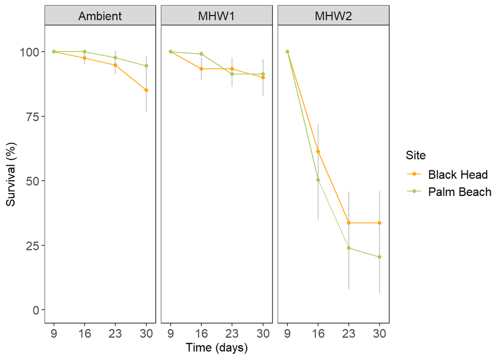

```r
Average_percentTank2$Day <- as.numeric(Average_percentTank2$Day)
Count_plot16 <- Average_percentTank2 %>%
  filter(Site == "Palm Beach" | Site == "Black Head") %>%
  filter(Day == 9|Day == 16|Day == 23| Day == 30)  %>%
ggplot(aes(x= Day, y= Percent_mean, colour = Site)) +
   geom_errorbar(aes(ymin=Percent_mean-se, ymax=Percent_mean+se),colour = "grey", width=.2) +
  geom_point() +
  geom_line()+
Theme1 +
labs( y="Survival (%)", x="Time (days)")  +
 scale_colour_manual(values = c("orange", "darkolivegreen3"))   +
theme(strip.text.x = element_text(size = 12))+
scale_y_continuous(limits = c(0, 105), breaks = seq(0, 100, by = 25))+
scale_x_continuous(limits = c(8, 31), breaks = c(9, 16, 23,30))+
facet_wrap(~ factor(Treatment, c("Ambient","MHW1","MHW2")), ncol = 3)


Count_plot16
```

```r
ggsave("Survival_germlings.jpeg", width = 200, height = 56, units = "mm")
```

#### 2. Statistical analyses

Filter data per day

```r
Percent_Tank <- filter (percentTank, Site == "Palm_Beach" | Site == "Black_Head")
Percent_Tank$Day <- as.factor(Percent_Tank$Day)
Percent_Tank$Proportion_Survival <- (Percent_Tank$Percent_survival)/100

Percent_TankALL <- filter (Percent_Tank, Day == "9" |Day == "16"|Day == "23" |Day == "30")
```

1. Run LMM for germling survival

```r
my_lm1 <- lmer(Proportion_Survival ~ Site*Treatment*Day + (1|TankCode), data=Percent_TankALL)
summary(my_lm1)
```

```
## Linear mixed model fit by REML ['lmerMod']
## Formula: Proportion_Survival ~ Site * Treatment * Day + (1 | TankCode)
##    Data: Percent_TankALL
##
## REML criterion at convergence: -48.6
##
## Scaled residuals:
##     Min      1Q  Median      3Q     Max
## -2.1660 -0.3941  0.0638  0.3180  3.4963
##
## Random effects:
##  Groups   Name        Variance Std.Dev.
##  TankCode (Intercept) 0.009781 0.0989
##  Residual             0.022633 0.1504
## Number of obs: 144, groups:  TankCode, 18
##
## Fixed effects:
##                                      Estimate Std. Error t value
## (Intercept)                         1.000e+00  7.350e-02  13.605
## SitePalm_Beach                     -1.925e-16  8.686e-02   0.000
## TreatmentMHW1                      -3.617e-15  1.039e-01   0.000
## TreatmentMHW2                      -5.550e-15  1.039e-01   0.000
## Day16                              -2.381e-02  8.686e-02  -0.274
## Day23                              -5.159e-02  8.686e-02  -0.594
## Day30                              -1.488e-01  8.686e-02  -1.713
## SitePalm_Beach:TreatmentMHW1       -3.371e-15  1.228e-01   0.000
## SitePalm_Beach:TreatmentMHW2       -6.119e-16  1.228e-01   0.000
## SitePalm_Beach:Day16                2.381e-02  1.228e-01   0.194
## SitePalm_Beach:Day23                2.937e-02  1.228e-01   0.239
## SitePalm_Beach:Day30                9.464e-02  1.228e-01   0.770
## TreatmentMHW1:Day16                -4.286e-02  1.228e-01  -0.349
## TreatmentMHW2:Day16                -3.623e-01  1.228e-01  -2.949
## TreatmentMHW1:Day23                -1.508e-02  1.228e-01  -0.123
## TreatmentMHW2:Day23                -6.123e-01  1.228e-01  -4.985
## TreatmentMHW1:Day30                 4.881e-02  1.228e-01   0.397
## TreatmentMHW2:Day30                -5.151e-01  1.228e-01  -4.193
## SitePalm_Beach:TreatmentMHW1:Day16  3.452e-02  1.737e-01   0.199
## SitePalm_Beach:TreatmentMHW2:Day16 -1.345e-01  1.737e-01  -0.774
## SitePalm_Beach:TreatmentMHW1:Day23 -4.980e-02  1.737e-01  -0.287
## SitePalm_Beach:TreatmentMHW2:Day23 -1.266e-01  1.737e-01  -0.729
## SitePalm_Beach:TreatmentMHW1:Day30 -8.174e-02  1.737e-01  -0.471
## SitePalm_Beach:TreatmentMHW2:Day30 -2.268e-01  1.737e-01  -1.305
```

```
##
## Correlation matrix not shown by default, as p = 24 > 12.
## Use print(x, correlation=TRUE)  or
##     vcov(x)        if you need it
```

```r
Anova(my_lm1)
```

```
## Analysis of Deviance Table (Type II Wald chisquare tests)
##
## Response: Proportion_Survival
##                      Chisq Df Pr(>Chisq)
## Site                0.2210  1     0.6383
## Treatment          57.6670  2  3.004e-13 ***
## Day                92.3452  3  < 2.2e-16 ***
## Site:Treatment      4.4208  2     0.1097
## Site:Day            0.1862  3     0.9798
## Treatment:Day      98.2682  6  < 2.2e-16 ***
## Site:Treatment:Day  2.2690  6     0.8934
## ---
## Signif. codes:  0 '***' 0.001 '**' 0.01 '*' 0.05 '.' 0.1 ' ' 1
```

```r
emmeans(my_lm1, specs = pairwise ~ Treatment|Day, type = "response", adjust = "none")
```

```
## NOTE: Results may be misleading due to involvement in interactions
```

```
## $emmeans
## Day = 9:
##  Treatment emmean     SE   df lower.CL upper.CL
##  Ambient    1.000 0.0593 39.4    0.880    1.120
##  MHW1       1.000 0.0593 39.4    0.880    1.120
##  MHW2       1.000 0.0593 39.4    0.880    1.120
##
## Day = 16:
##  Treatment emmean     SE   df lower.CL upper.CL
##  Ambient    0.988 0.0593 39.4    0.868    1.108
##  MHW1       0.963 0.0593 39.4    0.843    1.082
##  MHW2       0.559 0.0593 39.4    0.439    0.678
##
## Day = 23:
##  Treatment emmean     SE   df lower.CL upper.CL
##  Ambient    0.963 0.0593 39.4    0.843    1.083
##  MHW1       0.923 0.0593 39.4    0.803    1.043
##  MHW2       0.287 0.0593 39.4    0.168    0.407
##
## Day = 30:
##  Treatment emmean     SE   df lower.CL upper.CL
##  Ambient    0.899 0.0593 39.4    0.779    1.018
##  MHW1       0.906 0.0593 39.4    0.787    1.026
##  MHW2       0.270 0.0593 39.4    0.150    0.390
##
## Results are averaged over the levels of: Site
## Degrees-of-freedom method: kenward-roger
## Confidence level used: 0.95
##
## $contrasts
## Day = 9:
##  contrast       estimate     SE   df t.ratio p.value
##  Ambient - MHW1  0.00000 0.0839 39.4   0.000  1.0000
##  Ambient - MHW2  0.00000 0.0839 39.4   0.000  1.0000
##  MHW1 - MHW2     0.00000 0.0839 39.4   0.000  1.0000
##
## Day = 16:
##  contrast       estimate     SE   df t.ratio p.value
##  Ambient - MHW1  0.02560 0.0839 39.4   0.305  0.7618
##  Ambient - MHW2  0.42956 0.0839 39.4   5.122  <.0001
##  MHW1 - MHW2     0.40396 0.0839 39.4   4.817  <.0001
##
## Day = 23:
##  contrast       estimate     SE   df t.ratio p.value
##  Ambient - MHW1  0.03998 0.0839 39.4   0.477  0.6362
##  Ambient - MHW2  0.67560 0.0839 39.4   8.056  <.0001
##  MHW1 - MHW2     0.63562 0.0839 39.4   7.579  <.0001
##
## Day = 30:
##  contrast       estimate     SE   df t.ratio p.value
##  Ambient - MHW1 -0.00794 0.0839 39.4  -0.095  0.9251
##  Ambient - MHW2  0.62847 0.0839 39.4   7.494  <.0001
##  MHW1 - MHW2     0.63641 0.0839 39.4   7.589  <.0001
##
## Results are averaged over the levels of: Site
## Degrees-of-freedom method: kenward-roger
```

```r
emmeans(my_lm1, specs = pairwise ~ Day|Treatment, type = "response", adjust = "none")
```

```
## NOTE: Results may be misleading due to involvement in interactions
```

```
## $emmeans
## Treatment = Ambient:
##  Day emmean     SE   df lower.CL upper.CL
##  9    1.000 0.0593 39.4    0.880    1.120
##  16   0.988 0.0593 39.4    0.868    1.108
##  23   0.963 0.0593 39.4    0.843    1.083
##  30   0.899 0.0593 39.4    0.779    1.018
##
## Treatment = MHW1:
##  Day emmean     SE   df lower.CL upper.CL
##  9    1.000 0.0593 39.4    0.880    1.120
##  16   0.963 0.0593 39.4    0.843    1.082
##  23   0.923 0.0593 39.4    0.803    1.043
##  30   0.906 0.0593 39.4    0.787    1.026
##
## Treatment = MHW2:
##  Day emmean     SE   df lower.CL upper.CL
##  9    1.000 0.0593 39.4    0.880    1.120
##  16   0.559 0.0593 39.4    0.439    0.678
##  23   0.287 0.0593 39.4    0.168    0.407
##  30   0.270 0.0593 39.4    0.150    0.390
##
## Results are averaged over the levels of: Site
## Degrees-of-freedom method: kenward-roger
## Confidence level used: 0.95
##
## $contrasts
## Treatment = Ambient:
##  contrast      estimate     SE  df t.ratio p.value
##  Day9 - Day16    0.0119 0.0614 105   0.194  0.8467
##  Day9 - Day23    0.0369 0.0614 105   0.601  0.5492
##  Day9 - Day30    0.1015 0.0614 105   1.652  0.1014
##  Day16 - Day23   0.0250 0.0614 105   0.407  0.6848
##  Day16 - Day30   0.0896 0.0614 105   1.459  0.1477
##  Day23 - Day30   0.0646 0.0614 105   1.052  0.2954
##
## Treatment = MHW1:
##  contrast      estimate     SE  df t.ratio p.value
##  Day9 - Day16    0.0375 0.0614 105   0.611  0.5428
##  Day9 - Day23    0.0769 0.0614 105   1.252  0.2134
##  Day9 - Day30    0.0935 0.0614 105   1.523  0.1307
##  Day16 - Day23   0.0394 0.0614 105   0.641  0.5228
##  Day16 - Day30   0.0560 0.0614 105   0.913  0.3635
##  Day23 - Day30   0.0167 0.0614 105   0.271  0.7866
##
## Treatment = MHW2:
##  contrast      estimate     SE  df t.ratio p.value
##  Day9 - Day16    0.4415 0.0614 105   7.188  <.0001
##  Day9 - Day23    0.7125 0.0614 105  11.601  <.0001
##  Day9 - Day30    0.7300 0.0614 105  11.885  <.0001
##  Day16 - Day23   0.2710 0.0614 105   4.413  <.0001
##  Day16 - Day30   0.2885 0.0614 105   4.697  <.0001
##  Day23 - Day30   0.0175 0.0614 105   0.284  0.7768
##
## Results are averaged over the levels of: Site
## Degrees-of-freedom method: kenward-roger
```

Model check

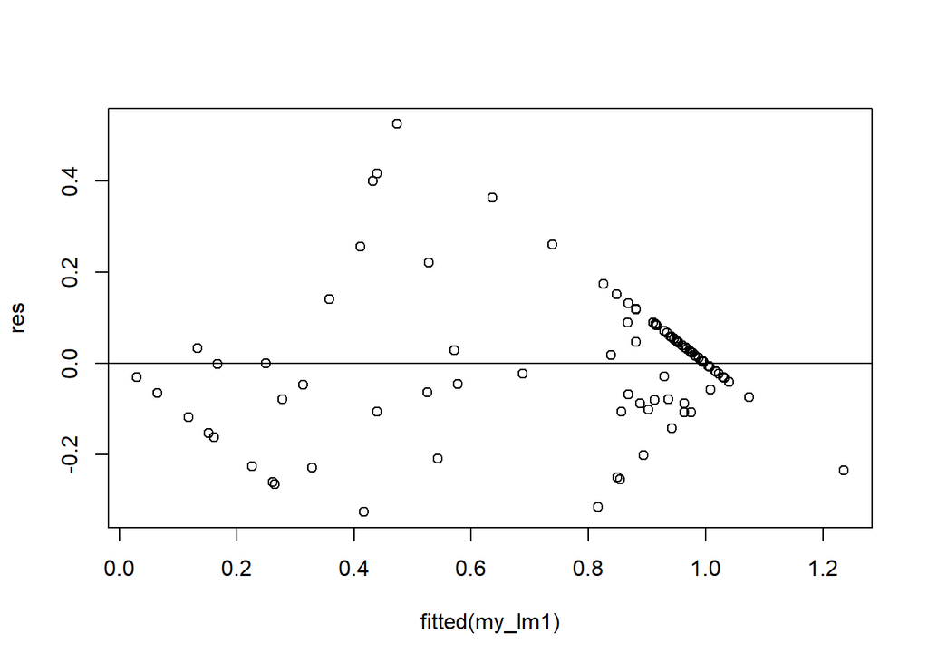

```r
res <- resid(my_lm1)
#produce residual vs. fitted plot
plot(fitted(my_lm1), res)

#add a horizontal line at 0
abline(0,0)
```

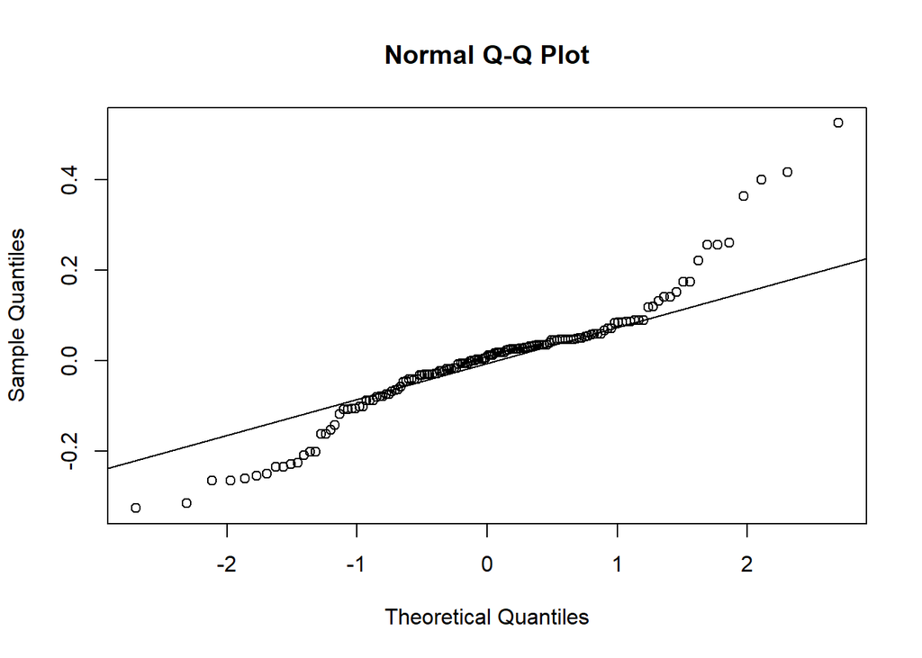

```r
#create Q-Q plot for residuals
qqnorm(res)

#add a straight diagonal line to the plot
qqline(res)
```

### **2b)** Germlings length

#### 1. Visualise differences

```r
Average_Length2 <- Average_Length
Average_Length2$Site <- factor(
  Average_Length2$Site,
  levels = c("Black_Head", "Palm_Beach"),
  labels = c(
    "Black Head",  "Palm Beach"
  ))
```

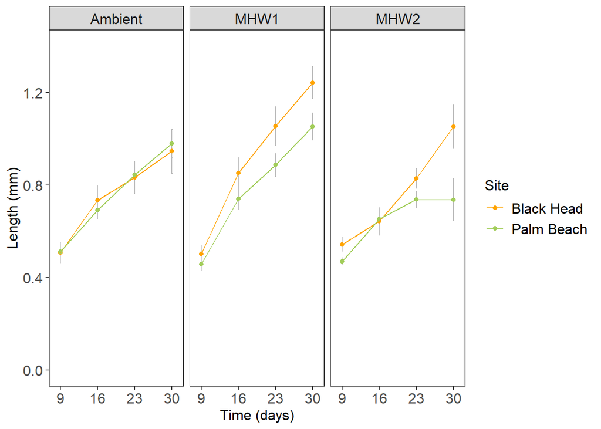

```r
Average_Length2$Day <- as.numeric(Average_Length2$Day)
Length_plot16 <- Average_Length2 %>%
  filter(Site == "Palm Beach" | Site == "Black Head")  %>%
  filter(Day == 9|Day == 16|Day == 23| Day == 30)   %>%
ggplot(aes(x= Day, y= MeanLength, colour = Site)) +
   geom_errorbar(aes(ymin=MeanLength-se, ymax=MeanLength+se),colour = "grey", width=.2) +
  geom_point() +
  geom_line()+
Theme1 +
labs( y="Length (mm)", x="Time (days)")  +
 scale_colour_manual(values = c("orange", "darkolivegreen3"))   +
theme(strip.text.x = element_text(size = 12))+
scale_y_continuous(limits = c(0, 1.4), breaks = seq(0, 1.2, by = 0.4))+
scale_x_continuous(limits = c(8, 31), breaks = c(9, 16, 23,30))+
facet_wrap(~ factor(Treatment, c("Ambient","MHW1","MHW2")), ncol = 3)



Length_plot16
```

```r
ggsave("Length_germlings.jpeg", width = 200, height = 56, units = "mm")
```

#### 2. Statistical analyses

1. Filter days to analyse and transform to factors

```r
Length_tank1 <- filter (Length_tank, Site == "Palm_Beach" | Site == "Black_Head")
Length_tank1$Day <- as.factor(Length_tank1$Day)

Length_wellALL <- filter (Length_tank1, Day == "9" |Day == "16"|Day == "23" |Day == "30")
```

2. Run linear model with site, MHW treatment and day as crossed fixed factors and water bath (tank) as random effect.

```r
my_lm2 <- lmer(Length_pertank ~ Site *Treatment*Day + (1|TankCode), data=Length_wellALL)
summary(my_lm2)
```

```
## Linear mixed model fit by REML ['lmerMod']
## Formula: Length_pertank ~ Site * Treatment * Day + (1 | TankCode)
##    Data: Length_wellALL
##
## REML criterion at convergence: -125.8
##
## Scaled residuals:
##     Min      1Q  Median      3Q     Max
## -2.2558 -0.5199 -0.0870  0.4616  2.5131
##
## Random effects:
##  Groups   Name        Variance Std.Dev.
##  TankCode (Intercept) 0.008366 0.09147
##  Residual             0.009279 0.09633
## Number of obs: 130, groups:  TankCode, 18
##
## Fixed effects:
##                                     Estimate Std. Error t value
## (Intercept)                         0.508597   0.054230   9.379
## SitePalm_Beach                      0.004407   0.055614   0.079
## TreatmentMHW1                      -0.005136   0.076692  -0.067
## TreatmentMHW2                       0.035769   0.076692   0.466
## Day16                               0.225199   0.055614   4.049
## Day23                               0.324519   0.055614   5.835
## Day30                               0.438128   0.055614   7.878
## SitePalm_Beach:TreatmentMHW1       -0.048668   0.078650  -0.619
## SitePalm_Beach:TreatmentMHW2       -0.078440   0.078650  -0.997
## SitePalm_Beach:Day16               -0.045828   0.078650  -0.583
## SitePalm_Beach:Day23                0.006854   0.078650   0.087
## SitePalm_Beach:Day30                0.029225   0.078650   0.372
## TreatmentMHW1:Day16                 0.124354   0.078650   1.581
## TreatmentMHW2:Day16                -0.117307   0.084381  -1.390
## TreatmentMHW1:Day23                 0.227569   0.078650   2.893
## TreatmentMHW2:Day23                -0.048874   0.084435  -0.579
## TreatmentMHW1:Day30                 0.301803   0.078650   3.837
## TreatmentMHW2:Day30                 0.060892   0.084435   0.721
## SitePalm_Beach:TreatmentMHW1:Day16 -0.022881   0.111227  -0.206
## SitePalm_Beach:TreatmentMHW2:Day16  0.118281   0.118740   0.996
## SitePalm_Beach:TreatmentMHW1:Day23 -0.131321   0.111227  -1.181
## SitePalm_Beach:TreatmentMHW2:Day23 -0.039591   0.122805  -0.322
## SitePalm_Beach:TreatmentMHW1:Day30 -0.174905   0.111227  -1.573
## SitePalm_Beach:TreatmentMHW2:Day30 -0.286736   0.122805  -2.335
```

```
##
## Correlation matrix not shown by default, as p = 24 > 12.
## Use print(x, correlation=TRUE)  or
##     vcov(x)        if you need it
```

```r
Anova(my_lm2)
```

```
## Analysis of Deviance Table (Type II Wald chisquare tests)
##
## Response: Length_pertank
##                       Chisq Df Pr(>Chisq)
## Site                19.3461  1  1.090e-05 ***
## Treatment            5.2572  2   0.072180 .
## Day                502.4284  3  < 2.2e-16 ***
## Site:Treatment      13.1551  2   0.001391 **
## Site:Day             4.8877  3   0.180210
## Treatment:Day       29.2349  6  5.492e-05 ***
## Site:Treatment:Day  11.7962  6   0.066672 .
## ---
## Signif. codes:  0 '***' 0.001 '**' 0.01 '*' 0.05 '.' 0.1 ' ' 1
```

3. Post-hoc test

```r
emmeans(my_lm2, specs = pairwise ~ Treatment|Site, type = "response", adjust = "none")
```

```
## NOTE: Results may be misleading due to involvement in interactions
```

```
## $emmeans
## Site = Black_Head:
##  Treatment emmean     SE   df lower.CL upper.CL
##  Ambient    0.756 0.0422 17.8    0.667    0.844
##  MHW1       0.914 0.0422 17.8    0.825    1.003
##  MHW2       0.765 0.0448 21.6    0.672    0.858
##
## Site = Palm_Beach:
##  Treatment emmean     SE   df lower.CL upper.CL
##  Ambient    0.758 0.0422 17.8    0.669    0.846
##  MHW1       0.785 0.0422 17.8    0.696    0.874
##  MHW2       0.637 0.0465 24.6    0.541    0.732
##
## Results are averaged over the levels of: Day
## Degrees-of-freedom method: kenward-roger
## Confidence level used: 0.95
##
## $contrasts
## Site = Black_Head:
##  contrast       estimate     SE   df t.ratio p.value
##  Ambient - MHW1 -0.15830 0.0597 17.8  -2.652  0.0163
##  Ambient - MHW2 -0.00945 0.0615 19.7  -0.154  0.8796
##  MHW1 - MHW2     0.14885 0.0615 19.7   2.419  0.0254
##
## Site = Palm_Beach:
##  contrast       estimate     SE   df t.ratio p.value
##  Ambient - MHW1 -0.02735 0.0597 17.8  -0.458  0.6523
##  Ambient - MHW2  0.12100 0.0628 21.2   1.926  0.0676
##  MHW1 - MHW2     0.14835 0.0628 21.2   2.362  0.0279
##
## Results are averaged over the levels of: Day
## Degrees-of-freedom method: kenward-roger
```

```r
emmeans(my_lm2, specs = pairwise ~ Site|Treatment, type = "response", adjust = "none")
```

```
## NOTE: Results may be misleading due to involvement in interactions
```

```
## $emmeans
## Treatment = Ambient:
##  Site       emmean     SE   df lower.CL upper.CL
##  Black_Head  0.756 0.0422 17.8    0.667    0.844
##  Palm_Beach  0.758 0.0422 17.8    0.669    0.846
##
## Treatment = MHW1:
##  Site       emmean     SE   df lower.CL upper.CL
##  Black_Head  0.914 0.0422 17.8    0.825    1.003
##  Palm_Beach  0.785 0.0422 17.8    0.696    0.874
##
## Treatment = MHW2:
##  Site       emmean     SE   df lower.CL upper.CL
##  Black_Head  0.765 0.0448 21.6    0.672    0.858
##  Palm_Beach  0.637 0.0465 24.6    0.541    0.732
##
## Results are averaged over the levels of: Day
## Degrees-of-freedom method: kenward-roger
## Confidence level used: 0.95
##
## $contrasts
## Treatment = Ambient:
##  contrast                estimate     SE   df t.ratio p.value
##  Black_Head - Palm_Beach -0.00197 0.0278 91.1  -0.071  0.9437
##
## Treatment = MHW1:
##  contrast                estimate     SE   df t.ratio p.value
##  Black_Head - Palm_Beach  0.12898 0.0278 91.1   4.638  <.0001
##
## Treatment = MHW2:
##  contrast                estimate     SE   df t.ratio p.value
##  Black_Head - Palm_Beach  0.12848 0.0362 95.3   3.545  0.0006
##
## Results are averaged over the levels of: Day
## Degrees-of-freedom method: kenward-roger
```

```r
emmeans(my_lm2, specs = pairwise ~ Day|Treatment, type = "response", adjust = "none")
```

```
## NOTE: Results may be misleading due to involvement in interactions
```

```
## $emmeans
## Treatment = Ambient:
##  Day emmean     SE   df lower.CL upper.CL
##  9    0.511 0.0466 26.0    0.415    0.607
##  16   0.713 0.0466 26.0    0.617    0.809
##  23   0.839 0.0466 26.0    0.743    0.934
##  30   0.964 0.0466 26.0    0.868    1.059
##
## Treatment = MHW1:
##  Day emmean     SE   df lower.CL upper.CL
##  9    0.481 0.0466 26.0    0.386    0.577
##  16   0.797 0.0466 26.0    0.701    0.892
##  23   0.971 0.0466 26.0    0.875    1.067
##  30   1.148 0.0466 26.0    1.053    1.244
##
## Treatment = MHW2:
##  Day emmean     SE   df lower.CL upper.CL
##  9    0.507 0.0466 26.0    0.412    0.603
##  16   0.651 0.0519 36.1    0.546    0.757
##  23   0.767 0.0538 40.8    0.658    0.875
##  30   0.878 0.0538 40.8    0.769    0.986
##
## Results are averaged over the levels of: Site
## Degrees-of-freedom method: kenward-roger
## Confidence level used: 0.95
##
## $contrasts
## Treatment = Ambient:
##  contrast      estimate     SE   df t.ratio p.value
##  Day9 - Day16    -0.202 0.0393 91.1  -5.144  <.0001
##  Day9 - Day23    -0.328 0.0393 91.1  -8.339  <.0001
##  Day9 - Day30    -0.453 0.0393 91.1 -11.513  <.0001
##  Day16 - Day23   -0.126 0.0393 91.1  -3.195  0.0019
##  Day16 - Day30   -0.250 0.0393 91.1  -6.369  <.0001
##  Day23 - Day30   -0.125 0.0393 91.1  -3.173  0.0021
##
## Treatment = MHW1:
##  contrast      estimate     SE   df t.ratio p.value
##  Day9 - Day16    -0.315 0.0393 91.1  -8.015  <.0001
##  Day9 - Day23    -0.490 0.0393 91.1 -12.457  <.0001
##  Day9 - Day30    -0.667 0.0393 91.1 -16.964  <.0001
##  Day16 - Day23   -0.175 0.0393 91.1  -4.441  <.0001
##  Day16 - Day30   -0.352 0.0393 91.1  -8.948  <.0001
##  Day23 - Day30   -0.177 0.0393 91.1  -4.507  <.0001
##
## Treatment = MHW2:
##  contrast      estimate     SE   df t.ratio p.value
##  Day9 - Day16    -0.144 0.0455 95.0  -3.169  0.0021
##  Day9 - Day23    -0.259 0.0477 94.8  -5.434  <.0001
##  Day9 - Day30    -0.370 0.0477 94.8  -7.761  <.0001
##  Day16 - Day23   -0.115 0.0508 91.9  -2.266  0.0258
##  Day16 - Day30   -0.226 0.0508 91.9  -4.450  <.0001
##  Day23 - Day30   -0.111 0.0520 91.1  -2.133  0.0356
##
## Results are averaged over the levels of: Site
## Degrees-of-freedom method: kenward-roger
```

```r
emmeans(my_lm2, specs = pairwise ~ Treatment|Day, type = "response", adjust = "none")
```

```
## NOTE: Results may be misleading due to involvement in interactions
```

```
## $emmeans
## Day = 9:
##  Treatment emmean     SE   df lower.CL upper.CL
##  Ambient    0.511 0.0466 26.0    0.415    0.607
##  MHW1       0.481 0.0466 26.0    0.386    0.577
##  MHW2       0.507 0.0466 26.0    0.412    0.603
##
## Day = 16:
##  Treatment emmean     SE   df lower.CL upper.CL
##  Ambient    0.713 0.0466 26.0    0.617    0.809
##  MHW1       0.797 0.0466 26.0    0.701    0.892
##  MHW2       0.651 0.0519 36.1    0.546    0.757
##
## Day = 23:
##  Treatment emmean     SE   df lower.CL upper.CL
##  Ambient    0.839 0.0466 26.0    0.743    0.934
##  MHW1       0.971 0.0466 26.0    0.875    1.067
##  MHW2       0.767 0.0538 40.8    0.658    0.875
##
## Day = 30:
##  Treatment emmean     SE   df lower.CL upper.CL
##  Ambient    0.964 0.0466 26.0    0.868    1.059
##  MHW1       1.148 0.0466 26.0    1.053    1.244
##  MHW2       0.878 0.0538 40.8    0.769    0.986
##
## Results are averaged over the levels of: Site
## Degrees-of-freedom method: kenward-roger
## Confidence level used: 0.95
##
## $contrasts
## Day = 9:
##  contrast       estimate     SE   df t.ratio p.value
##  Ambient - MHW1  0.02947 0.0658 26.0   0.448  0.6582
##  Ambient - MHW2  0.00345 0.0658 26.0   0.052  0.9586
##  MHW1 - MHW2    -0.02602 0.0658 26.0  -0.395  0.6959
##
## Day = 16:
##  contrast       estimate     SE   df t.ratio p.value
##  Ambient - MHW1 -0.08344 0.0658 26.0  -1.267  0.2163
##  Ambient - MHW2  0.06162 0.0697 31.1   0.884  0.3834
##  MHW1 - MHW2     0.14506 0.0697 31.1   2.081  0.0457
##
## Day = 23:
##  contrast       estimate     SE   df t.ratio p.value
##  Ambient - MHW1 -0.13244 0.0658 26.0  -2.011  0.0548
##  Ambient - MHW2  0.07212 0.0712 33.4   1.013  0.3182
##  MHW1 - MHW2     0.20456 0.0712 33.4   2.874  0.0070
##
## Day = 30:
##  contrast       estimate     SE   df t.ratio p.value
##  Ambient - MHW1 -0.18488 0.0658 26.0  -2.808  0.0093
##  Ambient - MHW2  0.08593 0.0712 33.4   1.207  0.2358
##  MHW1 - MHW2     0.27081 0.0712 33.4   3.805  0.0006
##
## Results are averaged over the levels of: Site
## Degrees-of-freedom method: kenward-roger
```

4. Check model assumptions

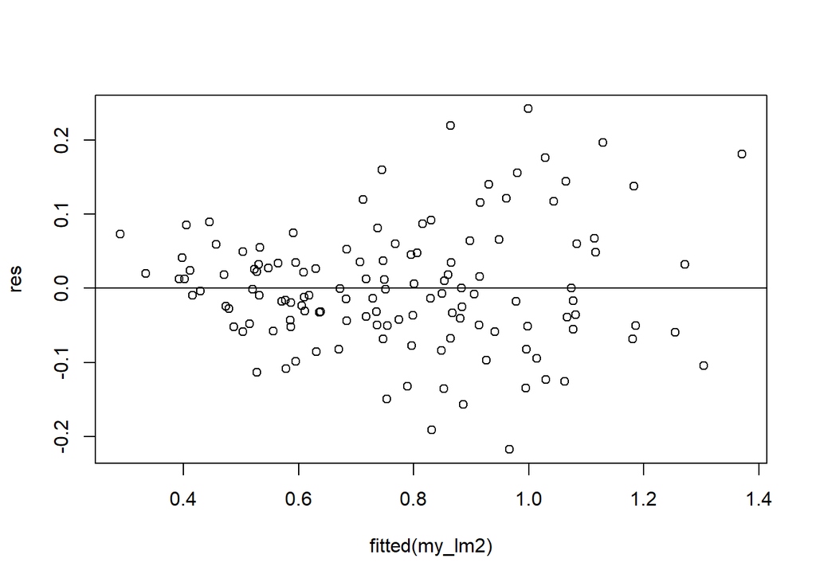

```r
res <- resid(my_lm2)
#produce residual vs. fitted plot
plot(fitted(my_lm2), res)

#add a horizontal line at 0
abline(0,0)
```

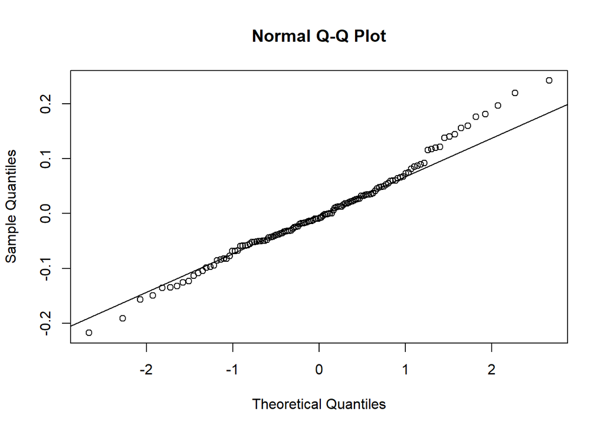

```r
#create Q-Q plot for residuals
qqnorm(res)

#add a straight diagonal line to the plot
qqline(res)
```

### **2c)** Germlings area

#### 1. Visualise differences

```r
Average_Area2 <- Average_Area
Average_Area2$Site <- factor(
  Average_Area2$Site,
  levels = c("Black_Head", "Palm_Beach"),
  labels = c(
    "Black Head",  "Palm Beach"
  ))
```

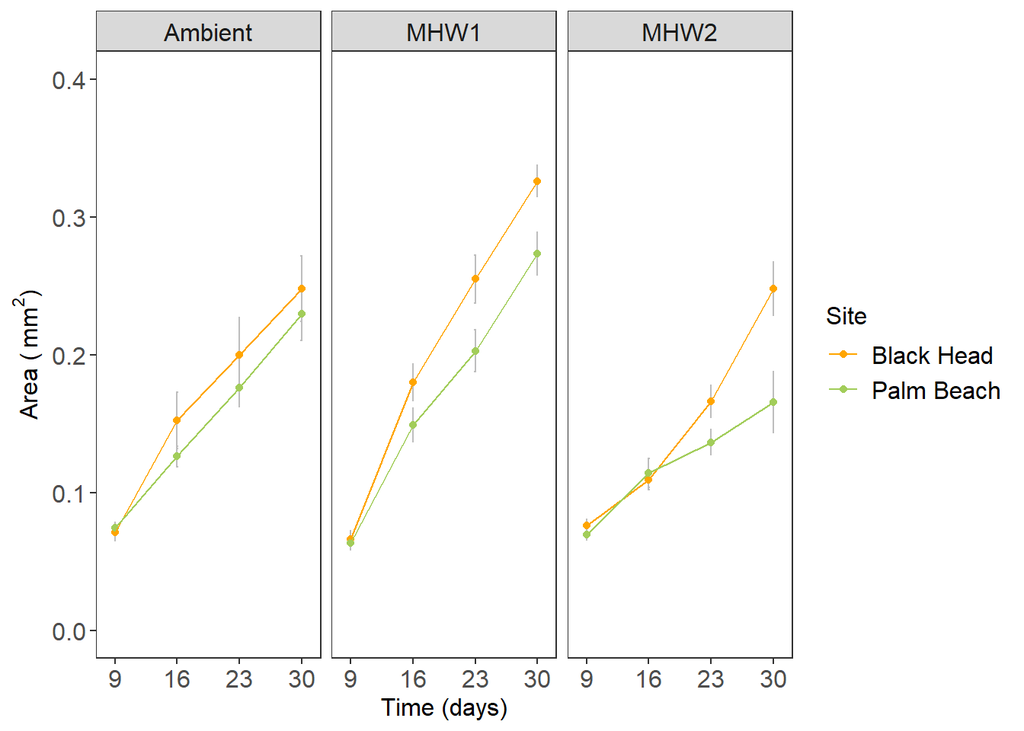

```r
Average_Area2$Day <- as.numeric(Average_Area2$Day)
Area_plot16 <- Average_Area2 %>%
  filter(Site == "Palm Beach" | Site == "Black Head")  %>%
  filter(Day == 9|Day == 16|Day == 23| Day == 30)    %>%
ggplot(aes(x= Day, y= MeanArea, colour = Site)) +
   geom_errorbar(aes(ymin=MeanArea-se, ymax=MeanArea+se),colour = "grey", width=.2) +
  geom_point() +
  geom_line()+
Theme1 +
labs( y="Area ("~mm^2*")", x="Time (days)")  +
 scale_colour_manual(values = c("orange", "darkolivegreen3"))   +
theme(strip.text.x = element_text(size = 12))+
scale_y_continuous(limits = c(0, 0.4), breaks = seq(0, 0.4, by = 0.1))+
scale_x_continuous(limits = c(8, 31), breaks = c(9, 16, 23,30))+
facet_wrap(~ factor(Treatment, c("Ambient","MHW1","MHW2")), ncol = 3)




Area_plot16
```

```r
ggsave("Area_germlings.jpeg", width = 200, height = 56, units = "mm")
```

#### 2. Statistical analyses

1. Choose only the days to analyse and transform them to factor

```r
Area_well1 <- filter (Area_tank, Site == "Palm_Beach" | Site == "Black_Head")
Area_well1$Day <- as.factor(Area_well1$Day)

Area_wellALL <- filter (Area_well1, Day == "9" |Day == "16"|Day == "23" |Day == "30")
```

2. Run linear model with site, MHW treatment and day as fixes/crossed factors and with water bath (Tank) as random intercept.

```r
my_lm2 <- lmer(Well_meanArea ~ Site *Treatment*Day + (1|TankCode), data=Area_wellALL)
my_lm_anova2 <- Anova(my_lm2)
my_lm_anova2
```

```
## Analysis of Deviance Table (Type II Wald chisquare tests)
##
## Response: Well_meanArea
##                       Chisq Df Pr(>Chisq)
## Site                29.6580  1  5.154e-08 ***
## Treatment           12.0648  2   0.002400 **
## Day                882.6266  3  < 2.2e-16 ***
## Site:Treatment       3.0722  2   0.215222
## Site:Day            13.7966  3   0.003195 **
## Treatment:Day       50.9940  6  2.970e-09 ***
## Site:Treatment:Day   8.5246  6   0.202129
## ---
## Signif. codes:  0 '***' 0.001 '**' 0.01 '*' 0.05 '.' 0.1 ' ' 1
```

3. Post-hoc test

```r
 emmeans(my_lm2, specs = pairwise ~ Treatment|Day, type = "response", adjust = "none")
```

```
## NOTE: Results may be misleading due to involvement in interactions
```

```
## $emmeans
## Day = 9:
##  Treatment emmean     SE   df lower.CL upper.CL
##  Ambient   0.0728 0.0115 29.1   0.0494   0.0963
##  MHW1      0.0652 0.0115 29.1   0.0417   0.0886
##  MHW2      0.0731 0.0115 29.1   0.0497   0.0966
##
## Day = 16:
##  Treatment emmean     SE   df lower.CL upper.CL
##  Ambient   0.1394 0.0115 29.1   0.1160   0.1628
##  MHW1      0.1646 0.0115 29.1   0.1411   0.1880
##  MHW2      0.1149 0.0130 41.2   0.0887   0.1411
##
## Day = 23:
##  Treatment emmean     SE   df lower.CL upper.CL
##  Ambient   0.1880 0.0115 29.1   0.1645   0.2114
##  MHW1      0.2290 0.0115 29.1   0.2056   0.2525
##  MHW2      0.1489 0.0135 46.9   0.1217   0.1762
##
## Day = 30:
##  Treatment emmean     SE   df lower.CL upper.CL
##  Ambient   0.2387 0.0115 29.1   0.2153   0.2621
##  MHW1      0.2998 0.0115 29.1   0.2764   0.3233
##  MHW2      0.2042 0.0135 46.9   0.1770   0.2314
##
## Results are averaged over the levels of: Site
## Degrees-of-freedom method: kenward-roger
## Confidence level used: 0.95
##
## $contrasts
## Day = 9:
##  contrast        estimate     SE   df t.ratio p.value
##  Ambient - MHW1  0.007662 0.0162 29.1   0.473  0.6401
##  Ambient - MHW2 -0.000288 0.0162 29.1  -0.018  0.9859
##  MHW1 - MHW2    -0.007950 0.0162 29.1  -0.490  0.6276
##
## Day = 16:
##  contrast        estimate     SE   df t.ratio p.value
##  Ambient - MHW1 -0.025159 0.0162 29.1  -1.552  0.1316
##  Ambient - MHW2  0.024517 0.0173 35.2   1.417  0.1654
##  MHW1 - MHW2     0.049676 0.0173 35.2   2.870  0.0069
##
## Day = 23:
##  contrast        estimate     SE   df t.ratio p.value
##  Ambient - MHW1 -0.041040 0.0162 29.1  -2.531  0.0170
##  Ambient - MHW2  0.039017 0.0177 38.1   2.201  0.0339
##  MHW1 - MHW2     0.080057 0.0177 38.1   4.516  0.0001
##
## Day = 30:
##  contrast        estimate     SE   df t.ratio p.value
##  Ambient - MHW1 -0.061107 0.0162 29.1  -3.769  0.0007
##  Ambient - MHW2  0.034497 0.0177 38.1   1.946  0.0591
##  MHW1 - MHW2     0.095604 0.0177 38.1   5.393  <.0001
##
## Results are averaged over the levels of: Site
## Degrees-of-freedom method: kenward-roger
```

```r
 emmeans(my_lm2, specs = pairwise ~ Day|Treatment, type = "response", adjust = "none")
```

```
## NOTE: Results may be misleading due to involvement in interactions
```

```
## $emmeans
## Treatment = Ambient:
##  Day emmean     SE   df lower.CL upper.CL
##  9   0.0728 0.0115 29.1   0.0494   0.0963
##  16  0.1394 0.0115 29.1   0.1160   0.1628
##  23  0.1880 0.0115 29.1   0.1645   0.2114
##  30  0.2387 0.0115 29.1   0.2153   0.2621
##
## Treatment = MHW1:
##  Day emmean     SE   df lower.CL upper.CL
##  9   0.0652 0.0115 29.1   0.0417   0.0886
##  16  0.1646 0.0115 29.1   0.1411   0.1880
##  23  0.2290 0.0115 29.1   0.2056   0.2525
##  30  0.2998 0.0115 29.1   0.2764   0.3233
##
## Treatment = MHW2:
##  Day emmean     SE   df lower.CL upper.CL
##  9   0.0731 0.0115 29.1   0.0497   0.0966
##  16  0.1149 0.0130 41.2   0.0887   0.1411
##  23  0.1489 0.0135 46.9   0.1217   0.1762
##  30  0.2042 0.0135 46.9   0.1770   0.2314
##
## Results are averaged over the levels of: Site
## Degrees-of-freedom method: kenward-roger
## Confidence level used: 0.95
##
## $contrasts
## Treatment = Ambient:
##  contrast      estimate     SE   df t.ratio p.value
##  Day9 - Day16   -0.0666 0.0105 91.1  -6.332  <.0001
##  Day9 - Day23   -0.1151 0.0105 91.1 -10.953  <.0001
##  Day9 - Day30   -0.1659 0.0105 91.1 -15.780  <.0001
##  Day16 - Day23  -0.0486 0.0105 91.1  -4.621  <.0001
##  Day16 - Day30  -0.0993 0.0105 91.1  -9.448  <.0001
##  Day23 - Day30  -0.0507 0.0105 91.1  -4.827  <.0001
##
## Treatment = MHW1:
##  contrast      estimate     SE   df t.ratio p.value
##  Day9 - Day16   -0.0994 0.0105 91.1  -9.455  <.0001
##  Day9 - Day23   -0.1638 0.0105 91.1 -15.587  <.0001
##  Day9 - Day30   -0.2346 0.0105 91.1 -22.323  <.0001
##  Day16 - Day23  -0.0644 0.0105 91.1  -6.132  <.0001
##  Day16 - Day30  -0.1352 0.0105 91.1 -12.868  <.0001
##  Day23 - Day30  -0.0708 0.0105 91.1  -6.736  <.0001
##
## Treatment = MHW2:
##  contrast      estimate     SE   df t.ratio p.value
##  Day9 - Day16   -0.0417 0.0121 95.5  -3.443  0.0009
##  Day9 - Day23   -0.0758 0.0127 95.3  -5.959  <.0001
##  Day9 - Day30   -0.1311 0.0127 95.3 -10.303  <.0001
##  Day16 - Day23  -0.0341 0.0136 92.1  -2.509  0.0139
##  Day16 - Day30  -0.0893 0.0136 92.1  -6.579  <.0001
##  Day23 - Day30  -0.0553 0.0139 91.1  -3.974  0.0001
##
## Results are averaged over the levels of: Site
## Degrees-of-freedom method: kenward-roger
```

```r
emmeans(my_lm2, specs = pairwise ~ Site|Day, type = "response", adjust = "none")
```

```
## NOTE: Results may be misleading due to involvement in interactions
```

```
## $emmeans
## Day = 9:
##  Site       emmean      SE   df lower.CL upper.CL
##  Black_Head 0.0714 0.00789 51.7   0.0555   0.0872
##  Palm_Beach 0.0694 0.00789 51.7   0.0536   0.0852
##
## Day = 16:
##  Site       emmean      SE   df lower.CL upper.CL
##  Black_Head 0.1486 0.00835 59.0   0.1319   0.1653
##  Palm_Beach 0.1307 0.00835 58.9   0.1139   0.1474
##
## Day = 23:
##  Site       emmean      SE   df lower.CL upper.CL
##  Black_Head 0.2064 0.00835 59.0   0.1897   0.2231
##  Palm_Beach 0.1709 0.00877 65.7   0.1534   0.1884
##
## Day = 30:
##  Site       emmean      SE   df lower.CL upper.CL
##  Black_Head 0.2733 0.00835 59.0   0.2566   0.2900
##  Palm_Beach 0.2218 0.00877 65.7   0.2043   0.2394
##
## Results are averaged over the levels of: Treatment
## Degrees-of-freedom method: kenward-roger
## Confidence level used: 0.95
##
## $contrasts
## Day = 9:
##  contrast                estimate      SE   df t.ratio p.value
##  Black_Head - Palm_Beach  0.00196 0.00858 91.1   0.228  0.8198
##
## Day = 16:
##  contrast                estimate      SE   df t.ratio p.value
##  Black_Head - Palm_Beach  0.01792 0.00935 91.8   1.917  0.0583
##
## Day = 23:
##  contrast                estimate      SE   df t.ratio p.value
##  Black_Head - Palm_Beach  0.03552 0.00976 92.7   3.640  0.0004
##
## Day = 30:
##  contrast                estimate      SE   df t.ratio p.value
##  Black_Head - Palm_Beach  0.05144 0.00976 92.7   5.272  <.0001
##
## Results are averaged over the levels of: Treatment
## Degrees-of-freedom method: kenward-roger
```

```r
emmeans(my_lm2, specs = pairwise ~ Day|Site, type = "response", adjust = "none")
```

```
## NOTE: Results may be misleading due to involvement in interactions
```

```
## $emmeans
## Site = Black_Head:
##  Day emmean      SE   df lower.CL upper.CL
##  9   0.0714 0.00789 51.7   0.0555   0.0872
##  16  0.1486 0.00835 59.0   0.1319   0.1653
##  23  0.2064 0.00835 59.0   0.1897   0.2231
##  30  0.2733 0.00835 59.0   0.2566   0.2900
##
## Site = Palm_Beach:
##  Day emmean      SE   df lower.CL upper.CL
##  9   0.0694 0.00789 51.7   0.0536   0.0852
##  16  0.1307 0.00835 58.9   0.1139   0.1474
##  23  0.1709 0.00877 65.7   0.1534   0.1884
##  30  0.2218 0.00877 65.7   0.2043   0.2394
##
## Results are averaged over the levels of: Treatment
## Degrees-of-freedom method: kenward-roger
## Confidence level used: 0.95
##
## $contrasts
## Site = Black_Head:
##  contrast      estimate      SE   df t.ratio p.value
##  Day9 - Day16   -0.0772 0.00900 92.2  -8.575  <.0001
##  Day9 - Day23   -0.1350 0.00901 92.2 -14.990  <.0001
##  Day9 - Day30   -0.2019 0.00901 92.2 -22.415  <.0001
##  Day16 - Day23  -0.0578 0.00934 91.7  -6.192  <.0001
##  Day16 - Day30  -0.1247 0.00934 91.7 -13.353  <.0001
##  Day23 - Day30  -0.0669 0.00927 91.1  -7.216  <.0001
##
## Site = Palm_Beach:
##  contrast      estimate      SE   df t.ratio p.value
##  Day9 - Day16   -0.0612 0.00901 92.3  -6.796  <.0001
##  Day9 - Day23   -0.1015 0.00940 92.7 -10.796  <.0001
##  Day9 - Day30   -0.1524 0.00940 92.7 -16.218  <.0001
##  Day16 - Day23  -0.0402 0.00964 91.5  -4.172  0.0001
##  Day16 - Day30  -0.0912 0.00964 91.5  -9.457  <.0001
##  Day23 - Day30  -0.0510 0.00991 91.1  -5.144  <.0001
##
## Results are averaged over the levels of: Treatment
## Degrees-of-freedom method: kenward-roger
```

4. Check model assumptions

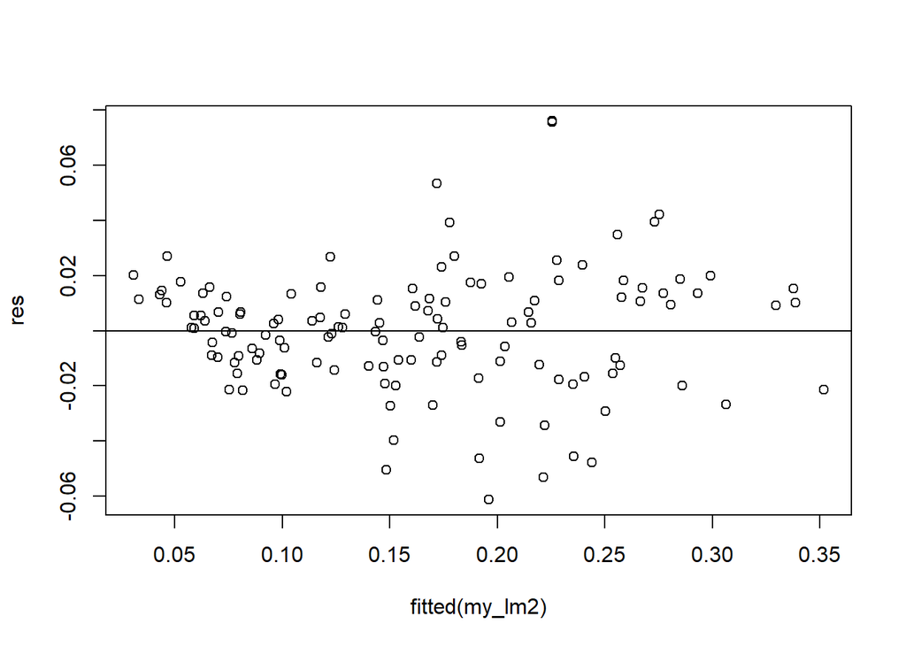

```r
res <- resid(my_lm2)
#produce residual vs. fitted plot
plot(fitted(my_lm2), res)

#add a horizontal line at 0
abline(0,0)
```

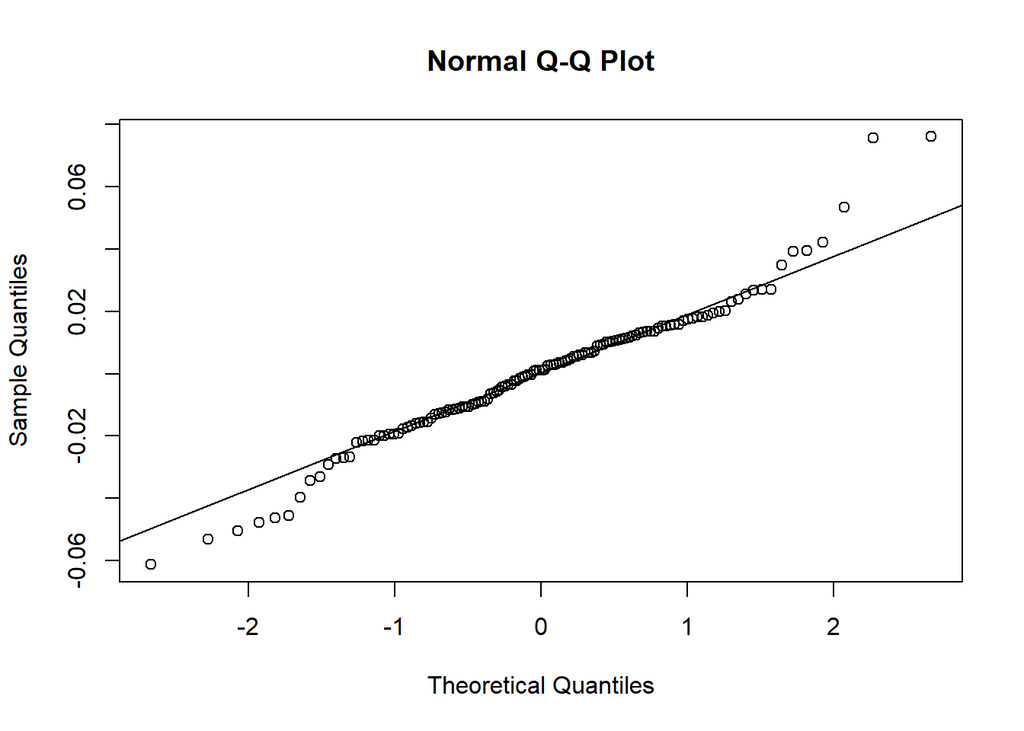

```r
#create Q-Q plot for residuals
qqnorm(res)

#add a straight diagonal line to the plot
qqline(res)
```

### **2d)** Shape

#### 1. Visualise differences

```r
Average_Shape2 <- Average_Shape
Average_Shape2$Site <- factor(
  Average_Shape$Site,
  levels = c("Palm_Beach", "Black_Head"),
  labels = c(
    "Palm Beach",
    "Black Head"
  ))
```

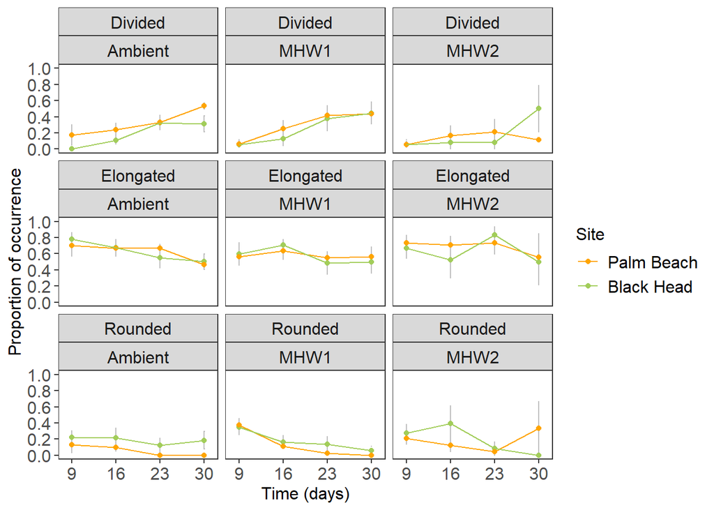

```r
Average_Shape2 <- Average_Shape2 %>%
  filter(Site == "Palm Beach" | Site == "Black Head") %>%
  filter(Day == 9|Day == 16|Day == 23| Day == 30)
Average_Shape2$Day <- as.numeric(Average_Shape2$Day)

Shapes <-  Average_Shape2  %>%
ggplot(aes(x= Day, y= MeanShape, colour = Site)) +
   geom_errorbar(aes(ymin=MeanShape-se, ymax=MeanShape+se),colour = "grey", width=.2) +
  geom_point() +
  geom_line()+
Theme1 +
labs( y="Proportion of occurrence", x="Time (days)")  +
 scale_colour_manual(values = c("orange", "darkolivegreen3"))   +
theme(strip.text.x = element_text(size = 12))+
scale_y_continuous(limits = c(0, 1), breaks = seq(0, 1, by = 0.2))+
scale_x_continuous(limits = c(8, 31), breaks = c(9, 16, 23,30))+
facet_wrap(~ Shape2 +factor(Treatment, c("Ambient","MHW1","MHW2")), ncol = 3)

Shapes
```

```r
ggsave("shape_germlings.jpeg", width = 180, height = 140, units = "mm")
```

#### 2. Statistical analyses

Separate by shape and select the days to analyse

```r
Shape_long <- filter (Shape_long, Site == "Palm_Beach" | Site == "Black_Head")
Shape_long$Day <- as.factor(Shape_long$Day)

Shape_el <- filter (Shape_long, Shape2 == "Elongated")
Shape_well1 <- filter (Shape_el, Day == "9" |Day == "16"|Day == "23" |Day == "30")


Shape_div <- filter (Shape_long, Shape2 == "Divided")
ShapeD_well1 <- filter (Shape_div, Day == "9" |Day == "16"|Day == "23" |Day == "30")

Shape_r <- filter (Shape_long, Shape2 == "Rounded")
ShapeR_well1 <- filter (Shape_r, Day == "9" |Day == "16"|Day == "23" |Day == "30")
```

##### 2.1. Branched (divided)

1. Run LMM for percentage of branched germlings

```r
my_lm2 <- lmer(percent ~ Site *Treatment*Day + (1|TankCode), data=ShapeD_well1)
summary(my_lm2)
```

```
## Linear mixed model fit by REML ['lmerMod']
## Formula: percent ~ Site * Treatment * Day + (1 | TankCode)
##    Data: ShapeD_well1
##
## REML criterion at convergence: 28.5
##
## Scaled residuals:
##     Min      1Q  Median      3Q     Max
## -2.1997 -0.4598 -0.1989  0.4701  2.7282
##
## Random effects:
##  Groups   Name        Variance  Std.Dev.
##  TankCode (Intercept) 0.0007258 0.02694
##  Residual             0.0518397 0.22768
## Number of obs: 130, groups:  TankCode, 18
##
## Fixed effects:
##                                      Estimate Std. Error t value
## (Intercept)                         3.645e-15  9.360e-02   0.000
## SitePalm_Beach                      1.726e-01  1.315e-01   1.313
## TreatmentMHW1                       5.556e-02  1.324e-01   0.420
## TreatmentMHW2                       5.556e-02  1.324e-01   0.420
## Day16                               1.087e-01  1.315e-01   0.827
## Day23                               3.250e-01  1.315e-01   2.472
## Day30                               3.111e-01  1.315e-01   2.367
## SitePalm_Beach:TreatmentMHW1       -1.671e-01  1.859e-01  -0.899
## SitePalm_Beach:TreatmentMHW2       -1.726e-01  1.859e-01  -0.929
## SitePalm_Beach:Day16               -4.524e-02  1.859e-01  -0.243
## SitePalm_Beach:Day23               -1.683e-01  1.859e-01  -0.905
## SitePalm_Beach:Day30                4.881e-02  1.859e-01   0.263
## TreatmentMHW1:Day16                -3.929e-02  1.859e-01  -0.211
## TreatmentMHW2:Day16                -7.931e-02  1.973e-01  -0.402
## TreatmentMHW1:Day23                -2.778e-03  1.859e-01  -0.015
## TreatmentMHW2:Day23                -2.993e-01  1.973e-01  -1.517
## TreatmentMHW1:Day30                 7.778e-02  1.859e-01   0.418
## TreatmentMHW2:Day30                 1.313e-01  1.973e-01   0.665
## SitePalm_Beach:TreatmentMHW1:Day16  1.647e-01  2.629e-01   0.626
## SitePalm_Beach:TreatmentMHW2:Day16  1.300e-01  2.790e-01   0.466
## SitePalm_Beach:TreatmentMHW1:Day23  2.036e-01  2.629e-01   0.774
## SitePalm_Beach:TreatmentMHW2:Day23  3.013e-01  2.868e-01   1.051
## SitePalm_Beach:TreatmentMHW1:Day30 -6.548e-02  2.629e-01  -0.249
## SitePalm_Beach:TreatmentMHW2:Day30 -4.356e-01  2.868e-01  -1.519
```

```
##
## Correlation matrix not shown by default, as p = 24 > 12.
## Use print(x, correlation=TRUE)  or
##     vcov(x)        if you need it
```

```r
Anova(my_lm2)
```

```
## Analysis of Deviance Table (Type II Wald chisquare tests)
##
## Response: percent
##                      Chisq Df Pr(>Chisq)
## Site                1.9257  1     0.1652
## Treatment           3.4810  2     0.1754
## Day                41.1430  3  6.098e-09 ***
## Site:Treatment      2.7048  2     0.2586
## Site:Day            1.2014  3     0.7527
## Treatment:Day       3.5466  6     0.7378
## Site:Treatment:Day  6.5824  6     0.3612
## ---
## Signif. codes:  0 '***' 0.001 '**' 0.01 '*' 0.05 '.' 0.1 ' ' 1
```

2. Post-hoc test

```r
emm5 = emmeans(my_lm2, specs = pairwise ~ Day, type = "response", adjust = "none")
```

```
## NOTE: Results may be misleading due to involvement in interactions
```

```r
emm5
```

```
## $emmeans
##  Day emmean     SE   df lower.CL upper.CL
##  9   0.0667 0.0385 88.0 -0.00973    0.143
##  16  0.1624 0.0416 91.3  0.07980    0.245
##  23  0.2911 0.0430 93.7  0.20559    0.377
##  30  0.3884 0.0430 93.7  0.30295    0.474
##
## Results are averaged over the levels of: Site, Treatment
## Degrees-of-freedom method: kenward-roger
## Confidence level used: 0.95
##
## $contrasts
##  contrast      estimate     SE   df t.ratio p.value
##  Day9 - Day16   -0.0957 0.0559 94.1  -1.711  0.0905
##  Day9 - Day23   -0.2243 0.0570 94.4  -3.933  0.0002
##  Day9 - Day30   -0.3217 0.0570 94.4  -5.640  <.0001
##  Day16 - Day23  -0.1286 0.0591 93.7  -2.176  0.0321
##  Day16 - Day30  -0.2260 0.0591 93.7  -3.823  0.0002
##  Day23 - Day30  -0.0974 0.0600 91.8  -1.623  0.1081
##
## Results are averaged over the levels of: Site, Treatment
## Degrees-of-freedom method: kenward-roger
```

3. Check model assumptions

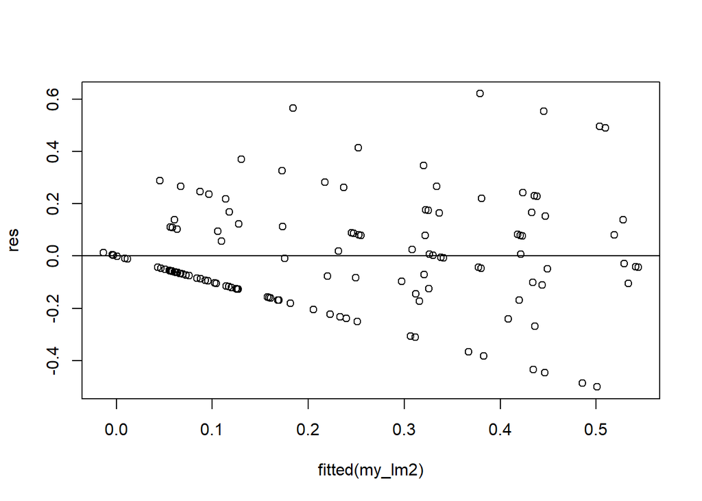

```r
res <- resid(my_lm2)
#produce residual vs. fitted plot
plot(fitted(my_lm2), res)

#add a horizontal line at 0
abline(0,0)
```

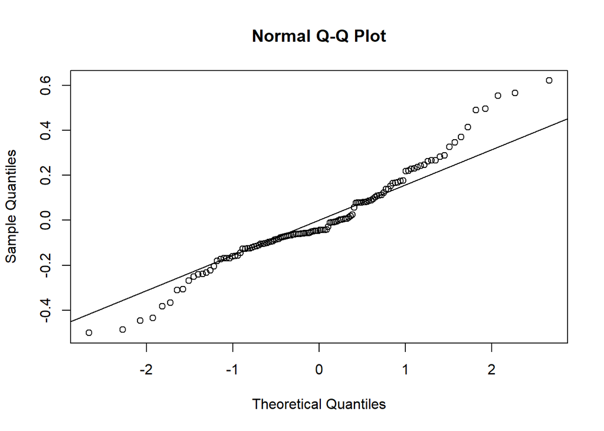

```r
#create Q-Q plot for residuals
qqnorm(res)

#add a straight diagonal line to the plot
qqline(res)
```

##### 2.2. Elongated

1. Run LMM for percentage of elongated germlings

```r
my_lm2 <- lmer(percent ~ Site *Treatment*Day + (1|TankCode), data=Shape_well1)
summary(my_lm2)
```

```
## Linear mixed model fit by REML ['lmerMod']
## Formula: percent ~ Site * Treatment * Day + (1 | TankCode)
##    Data: Shape_well1
##
## REML criterion at convergence: 65.6
##
## Scaled residuals:
##      Min       1Q   Median       3Q      Max
## -2.09880 -0.59045 -0.01315  0.62542  1.97960
##
## Random effects:
##  Groups   Name        Variance Std.Dev.
##  TankCode (Intercept) 0.008365 0.09146
##  Residual             0.068313 0.26137
## Number of obs: 130, groups:  TankCode, 18
##
## Fixed effects:
##                                    Estimate Std. Error t value
## (Intercept)                         0.77778    0.11305   6.880
## SitePalm_Beach                     -0.07817    0.15090  -0.518
## TreatmentMHW1                      -0.18333    0.15987  -1.147
## TreatmentMHW2                      -0.10833    0.15987  -0.678
## Day16                              -0.10476    0.15090  -0.694
## Day23                              -0.22778    0.15090  -1.509
## Day30                              -0.27500    0.15090  -1.822
## SitePalm_Beach:TreatmentMHW1        0.05040    0.21341   0.236
## SitePalm_Beach:TreatmentMHW2        0.14206    0.21341   0.666
## SitePalm_Beach:Day16                0.07183    0.21341   0.337
## SitePalm_Beach:Day23                0.19881    0.21341   0.932
## SitePalm_Beach:Day30                0.04286    0.21341   0.201
## TreatmentMHW1:Day16                 0.21865    0.21341   1.025
## TreatmentMHW2:Day16                -0.05253    0.22736  -0.231
## TreatmentMHW1:Day23                 0.11667    0.21341   0.547
## TreatmentMHW2:Day23                 0.39036    0.22740   1.717
## TreatmentMHW1:Day30                 0.18056    0.21341   0.846
## TreatmentMHW2:Day30                 0.10425    0.22740   0.458
## SitePalm_Beach:TreatmentMHW1:Day16 -0.11349    0.30180  -0.376
## SitePalm_Beach:TreatmentMHW2:Day16  0.03812    0.32109   0.119
## SitePalm_Beach:TreatmentMHW1:Day23 -0.10079    0.30180  -0.334
## SitePalm_Beach:TreatmentMHW2:Day23 -0.37345    0.33087  -1.129
## SitePalm_Beach:TreatmentMHW1:Day30  0.05159    0.30180   0.171
## SitePalm_Beach:TreatmentMHW2:Day30 -0.06670    0.33087  -0.202
```

```
##
## Correlation matrix not shown by default, as p = 24 > 12.
## Use print(x, correlation=TRUE)  or
##     vcov(x)        if you need it
```

```r
Anova(my_lm2)
```

```
## Analysis of Deviance Table (Type II Wald chisquare tests)
##
## Response: percent
##                     Chisq Df Pr(>Chisq)
## Site               0.1305  1     0.7179
## Treatment          0.8582  2     0.6511
## Day                7.0093  3     0.0716 .
## Site:Treatment     0.2492  2     0.8829
## Site:Day           0.3061  3     0.9589
## Treatment:Day      6.1533  6     0.4062
## Site:Treatment:Day 2.3889  6     0.8807
## ---
## Signif. codes:  0 '***' 0.001 '**' 0.01 '*' 0.05 '.' 0.1 ' ' 1
```

2. Post-hoc test

```r
emm5 = emmeans(my_lm2, specs = pairwise ~ Day, type = "response", adjust = "none")
```

```
## NOTE: Results may be misleading due to involvement in interactions
```

```r
emm5
```

```
## $emmeans
##  Day emmean     SE   df lower.CL upper.CL
##  9    0.674 0.0486 63.4    0.576    0.771
##  16   0.648 0.0522 69.7    0.543    0.752
##  23   0.635 0.0537 73.5    0.528    0.742
##  30   0.512 0.0537 73.5    0.405    0.619
##
## Results are averaged over the levels of: Site, Treatment
## Degrees-of-freedom method: kenward-roger
## Confidence level used: 0.95
##
## $contrasts
##  contrast      estimate     SE   df t.ratio p.value
##  Day9 - Day16    0.0260 0.0645 93.8   0.404  0.6872
##  Day9 - Day23    0.0384 0.0657 94.0   0.584  0.5605
##  Day9 - Day30    0.1612 0.0657 94.0   2.452  0.0161
##  Day16 - Day23   0.0124 0.0680 92.8   0.182  0.8561
##  Day16 - Day30   0.1351 0.0680 92.8   1.987  0.0498
##  Day23 - Day30   0.1228 0.0689 91.5   1.782  0.0780
##
## Results are averaged over the levels of: Site, Treatment
## Degrees-of-freedom method: kenward-roger
```

3. Check model assumptions

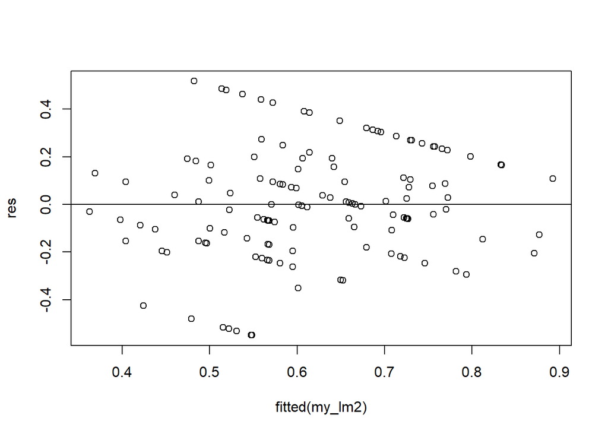

```r
res <- resid(my_lm2)
#produce residual vs. fitted plot
plot(fitted(my_lm2), res)

#add a horizontal line at 0
abline(0,0)
```

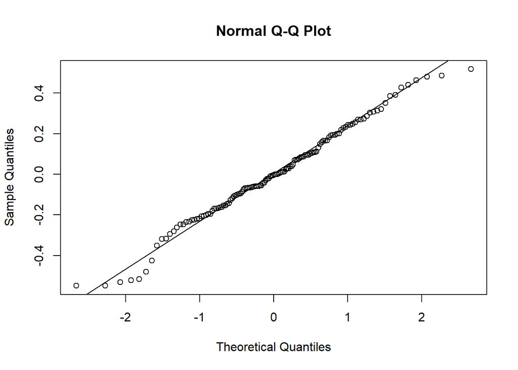

```r
#create Q-Q plot for residuals
qqnorm(res)

#add a straight diagonal line to the plot
qqline(res)
```

##### 2.3. Rounded

1. Run LMM for percentage of rounded germlings

```r
my_lm2 <- lmer(percent ~ Site *Treatment*Day + (1|TankCode), data=ShapeR_well1)
summary(my_lm2)
```

```
## Linear mixed model fit by REML ['lmerMod']
## Formula: percent ~ Site * Treatment * Day + (1 | TankCode)
##    Data: ShapeR_well1
##
## REML criterion at convergence: -4.7
##
## Scaled residuals:
##     Min      1Q  Median      3Q     Max
## -1.8955 -0.4793 -0.0982  0.4476  3.2300
##
## Random effects:
##  Groups   Name        Variance Std.Dev.
##  TankCode (Intercept) 0.01209  0.1099
##  Residual             0.03205  0.1790
## Number of obs: 130, groups:  TankCode, 18
##
## Fixed effects:
##                                     Estimate Std. Error t value
## (Intercept)                         0.222222   0.085774   2.591
## SitePalm_Beach                     -0.094444   0.103367  -0.914
## TreatmentMHW1                       0.127778   0.121303   1.053
## TreatmentMHW2                       0.052778   0.121303   0.435
## Day16                              -0.003968   0.103367  -0.038
## Day23                              -0.097222   0.103367  -0.941
## Day30                              -0.036111   0.103367  -0.349
## SitePalm_Beach:TreatmentMHW1        0.116667   0.146183   0.798
## SitePalm_Beach:TreatmentMHW2        0.030556   0.146183   0.209
## SitePalm_Beach:Day16               -0.026587   0.146183  -0.182
## SitePalm_Beach:Day23               -0.030556   0.146183  -0.209
## SitePalm_Beach:Day30               -0.091667   0.146183  -0.627
## TreatmentMHW1:Day16                -0.179365   0.146183  -1.227
## TreatmentMHW2:Day16                 0.124923   0.156356   0.799
## TreatmentMHW1:Day23                -0.113889   0.146183  -0.779
## TreatmentMHW2:Day23                -0.073130   0.156422  -0.468
## TreatmentMHW1:Day30                -0.258333   0.146183  -1.767
## TreatmentMHW2:Day30                -0.217575   0.156422  -1.391
## SitePalm_Beach:TreatmentMHW1:Day16 -0.051190   0.206734  -0.248
## SitePalm_Beach:TreatmentMHW2:Day16 -0.173338   0.220419  -0.786
## SitePalm_Beach:TreatmentMHW1:Day23 -0.102778   0.206734  -0.497
## SitePalm_Beach:TreatmentMHW2:Day23  0.061443   0.227643   0.270
## SitePalm_Beach:TreatmentMHW1:Day30  0.013889   0.206734   0.067
## SitePalm_Beach:TreatmentMHW2:Day30  0.491602   0.227643   2.160
```

```
##
## Correlation matrix not shown by default, as p = 24 > 12.
## Use print(x, correlation=TRUE)  or
##     vcov(x)        if you need it
```

```r
Anova(my_lm2)
```

```
## Analysis of Deviance Table (Type II Wald chisquare tests)
##
## Response: percent
##                      Chisq Df Pr(>Chisq)
## Site                5.6784  1    0.01717 *
## Treatment           0.5534  2    0.75826
## Day                22.1363  3  6.111e-05 ***
## Site:Treatment      1.8918  2    0.38834
## Site:Day            1.8542  3    0.60321
## Treatment:Day       9.5694  6    0.14400
## Site:Treatment:Day  9.8251  6    0.13221
## ---
## Signif. codes:  0 '***' 0.001 '**' 0.01 '*' 0.05 '.' 0.1 ' ' 1
```

2. Post-hoc test

```r
emm5 = emmeans(my_lm2, specs = pairwise ~ Day, type = "response", adjust = "none")
```

```
## NOTE: Results may be misleading due to involvement in interactions
```

```r
emm5
```

```
## $emmeans
##  Day emmean     SE   df lower.CL upper.CL
##  9    0.260 0.0395 38.9  0.17977    0.340
##  16   0.187 0.0418 44.6  0.10265    0.271
##  23   0.078 0.0427 47.5 -0.00798    0.164
##  30   0.103 0.0427 47.5  0.01741    0.189
##
## Results are averaged over the levels of: Site, Treatment
## Degrees-of-freedom method: kenward-roger
## Confidence level used: 0.95
##
## $contrasts
##  contrast      estimate     SE   df t.ratio p.value
##  Day9 - Day16    0.0728 0.0444 93.3   1.642  0.1040
##  Day9 - Day23    0.1817 0.0452 93.4   4.017  0.0001
##  Day9 - Day30    0.1563 0.0452 93.4   3.456  0.0008
##  Day16 - Day23   0.1089 0.0466 91.9   2.335  0.0217
##  Day16 - Day30   0.0835 0.0466 91.9   1.790  0.0767
##  Day23 - Day30  -0.0254 0.0472 91.2  -0.538  0.5917
##
## Results are averaged over the levels of: Site, Treatment
## Degrees-of-freedom method: kenward-roger
```

```r
emm5 = emmeans(my_lm2, specs = pairwise ~ Site, type = "response", adjust = "none")
```

```
## NOTE: Results may be misleading due to involvement in interactions
```

```r
emm5
```

```
## $emmeans
##  Site       emmean     SE   df lower.CL upper.CL
##  Black_Head  0.188 0.0346 23.4   0.1168    0.260
##  Palm_Beach  0.126 0.0354 25.0   0.0528    0.199
##
## Results are averaged over the levels of: Treatment, Day
## Degrees-of-freedom method: kenward-roger
## Confidence level used: 0.95
##
## $contrasts
##  contrast                estimate    SE   df t.ratio p.value
##  Black_Head - Palm_Beach   0.0626 0.033 94.7   1.897  0.0608
##
## Results are averaged over the levels of: Treatment, Day
## Degrees-of-freedom method: kenward-roger
```

3. Check model assumptions

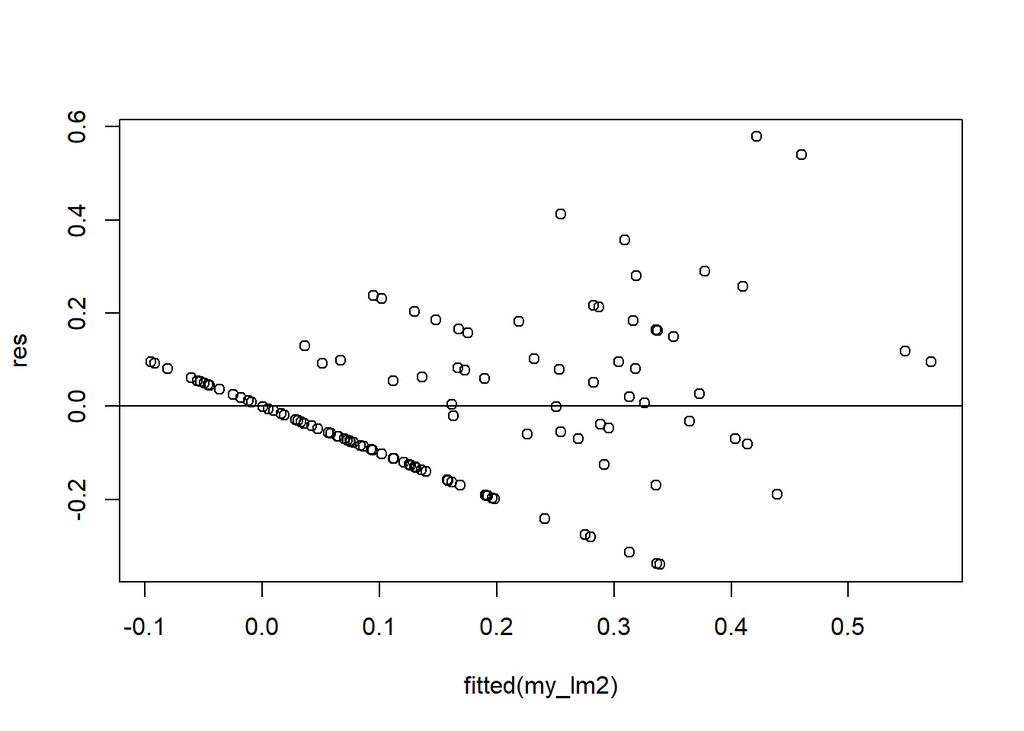

```r
res <- resid(my_lm2)
#produce residual vs. fitted plot
plot(fitted(my_lm2), res)

#add a horizontal line at 0
abline(0,0)
```

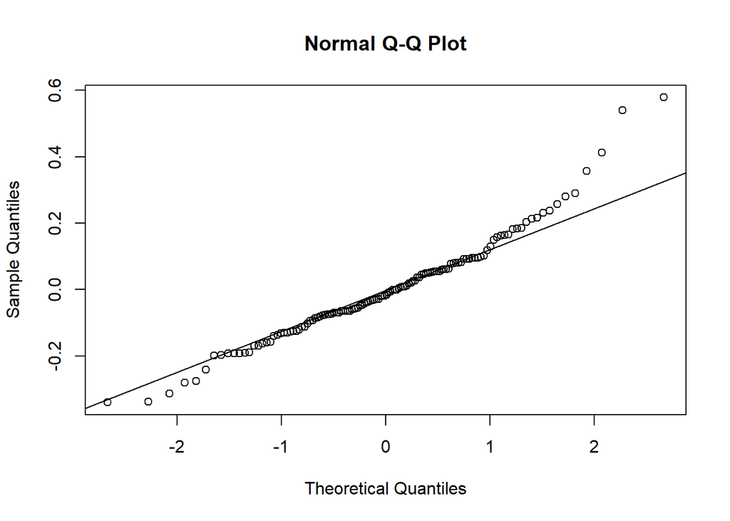

```r
#create Q-Q plot for residuals
qqnorm(res)

#add a straight diagonal line to the plot
qqline(res)
```

## **Section 3:** Juvenile experiments

### **3a)** Survival

#### 1. Visualise differences

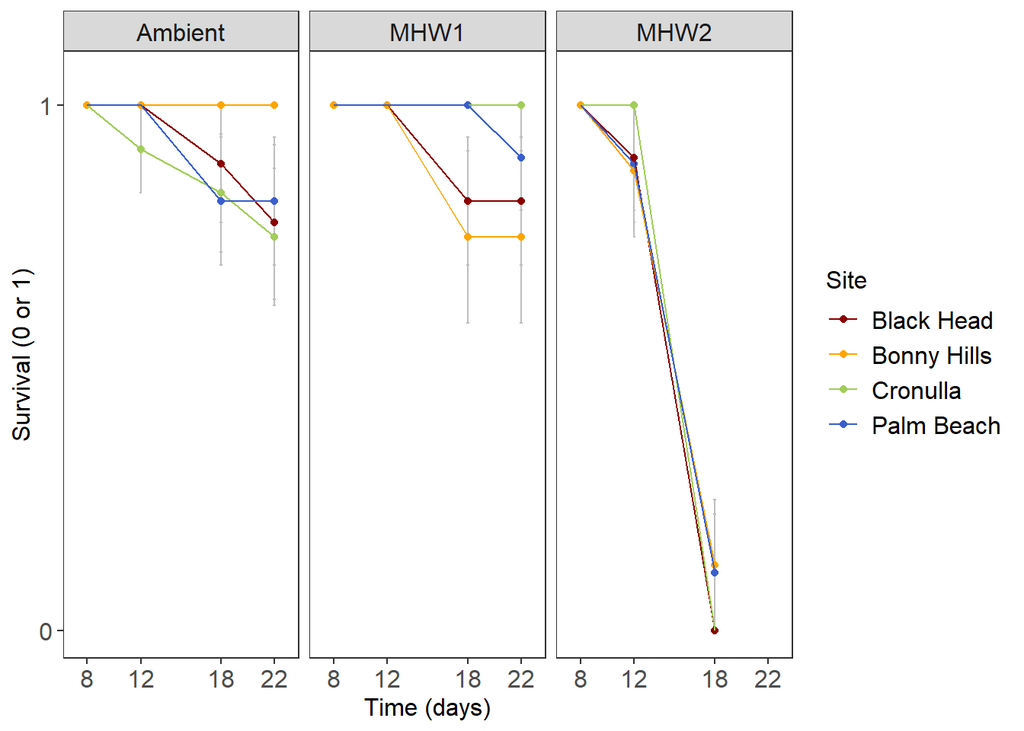

```r
surv_plot <- Juv_means %>%
  filter(Day_equivalent == 8|Day_equivalent == 12|Day_equivalent == 18| Day_equivalent == 22)  %>%
ggplot(aes(x= Day_equivalent, y= Mean_survival, colour = Site)) +
   geom_errorbar(aes(ymin=Mean_survival-se_surv, ymax=Mean_survival+se_surv),colour = "grey", width=.2) +
  geom_point() +
  geom_line()+
Theme1 +
labs( y="Survival (0 or 1)", x="Time (days)")  +
 scale_colour_manual(values = c("darkred", "orange", "darkolivegreen3", "royalblue3"))   +
theme(strip.text.x = element_text(size = 12))+
scale_y_continuous(limits = c(0, 1.05), breaks = seq(0, 1, by = 1))+
scale_x_continuous(limits = c(7, 23), breaks = c(8, 12, 18,22))+
facet_wrap(~ factor(Treatment, c("Ambient","MHW1","MHW2")), ncol = 3)

surv_plot
```

```r
ggsave("Survival01_juv.jpeg", width = 220, height = 60, units = "mm")
```

#### 2. Statistical analyses

1. Separate data by day

```r
Juveniles_meta$Tank_Code <- as.factor(Juveniles_meta$Tank_Code)
Juveniles_meta$Day_equivalent <- as.factor(Juveniles_meta$Day_equivalent)

##Filter Juveniles_meta for survival and holdfast analyses
Juveniles_stat8_1<- Juveniles_meta%>%
filter( Day_equivalent == "8")
Juveniles_stat12_1<- Juveniles_meta%>%
filter( Day_equivalent == "12")
Juveniles_stat18_1<- Juveniles_meta%>%
filter( Day_equivalent == "18")
Juveniles_stat22_1<- Juveniles_meta%>%
filter( Day_equivalent == "22")
Juveniles_stat1<- Juveniles_meta %>%
filter(Day_equivalent == "8"|Day_equivalent == "12"| Day_equivalent == "18"| Day_equivalent == "22")
```

##### 2.1. Day 12

1. Run LMM for survival at day 12

```r
my_glmer<- glmer(Survival_code ~ Site*Treatment + (1|Location), data=Juveniles_stat12_1, family = binomial)
summary(my_glmer)
```

```
## Generalized linear mixed model fit by maximum likelihood (Laplace
##   Approximation) [glmerMod]
##  Family: binomial  ( logit )
## Formula: Survival_code ~ Site * Treatment + (1 | Location)
##    Data: Juveniles_stat12_1
##
##      AIC      BIC   logLik deviance df.resid
##     51.6     88.0    -12.8     25.6      109
##
## Scaled residuals:
##      Min       1Q   Median       3Q      Max
## -2.92019  0.00001  0.00002  0.24255  0.45208
##
## Random effects:
##  Groups   Name        Variance Std.Dev.
##  Location (Intercept) 0.4635   0.6808
## Number of obs: 122, groups:  Location, 6
##
## Fixed effects:
##                                 Estimate Std. Error z value Pr(>|z|)
## (Intercept)                    2.273e+01  2.977e+04   0.001    0.999
## SiteBonny Hills               -1.980e-01  3.973e+04   0.000    1.000
## SiteCronulla                  -2.014e+01  2.977e+04  -0.001    0.999
## SitePalm Beach                 5.389e-01  4.436e+04   0.000    1.000
## TreatmentMHW1                  5.481e+00  3.838e+05   0.000    1.000
## TreatmentMHW2                 -2.041e+01  2.977e+04  -0.001    0.999
## SiteBonny Hills:TreatmentMHW1 -1.822e+00  4.195e+05   0.000    1.000
## SiteCronulla:TreatmentMHW1     1.321e+01  3.840e+05   0.000    1.000
## SitePalm Beach:TreatmentMHW1  -6.823e+00  3.856e+05   0.000    1.000
## SiteBonny Hills:TreatmentMHW2 -5.943e-02  3.973e+04   0.000    1.000
## SiteCronulla:TreatmentMHW2     3.855e+01  3.104e+04   0.001    0.999
## SitePalm Beach:TreatmentMHW2  -6.994e-01  4.436e+04   0.000    1.000
##
## Correlation of Fixed Effects:
##             (Intr) StBnnH StCrnl StPlmB TrMHW1 TrMHW2 SBH:TMHW1 SC:TMHW1
## SitBnnyHlls -0.749
## SiteCronull -1.000  0.749
## SitePalmBch -0.671  0.503  0.671
## TretmntMHW1 -0.078  0.058  0.078  0.052
## TretmntMHW2 -1.000  0.749  1.000  0.671  0.078
## StBHl:TMHW1  0.071 -0.095 -0.071 -0.048 -0.915 -0.071
## StCrn:TMHW1  0.078 -0.058 -0.078 -0.052 -1.000 -0.078  0.914
## StPBc:TMHW1  0.077 -0.058 -0.077 -0.115 -0.995 -0.077  0.911     0.995
## StBHl:TMHW2  0.749 -1.000 -0.749 -0.503 -0.058 -0.749  0.095     0.058
## StCrn:TMHW2  0.959 -0.718 -0.959 -0.643 -0.074 -0.959  0.068     0.074
## StPBc:TMHW2  0.671 -0.503 -0.671 -1.000 -0.052 -0.671  0.048     0.052
##             SPB:TMHW1 SBH:TMHW2 SC:TMHW2
## SitBnnyHlls
## SiteCronull
## SitePalmBch
## TretmntMHW1
## TretmntMHW2
## StBHl:TMHW1
## StCrn:TMHW1
## StPBc:TMHW1
## StBHl:TMHW2  0.058
## StCrn:TMHW2  0.074     0.718
## StPBc:TMHW2  0.115     0.503     0.643
## optimizer (Nelder_Mead) convergence code: 0 (OK)
## unable to evaluate scaled gradient
##  Hessian is numerically singular: parameters are not uniquely determined
```

```r
my_glmer_anova <- car::Anova(my_glmer)
my_glmer_anova
```

```
## Analysis of Deviance Table (Type II Wald chisquare tests)
##
## Response: Survival_code
##                 Chisq Df Pr(>Chisq)
## Site           0.0274  3     0.9988
## Treatment      0.0000  2     1.0000
## Site:Treatment 0.0000  6     1.0000
```

```r
overdisp.glmer(my_glmer)
```

```
## Residual deviance: 23.031 on 109 degrees of freedom (ratio: 0.211)
```

2. Check model assumptions

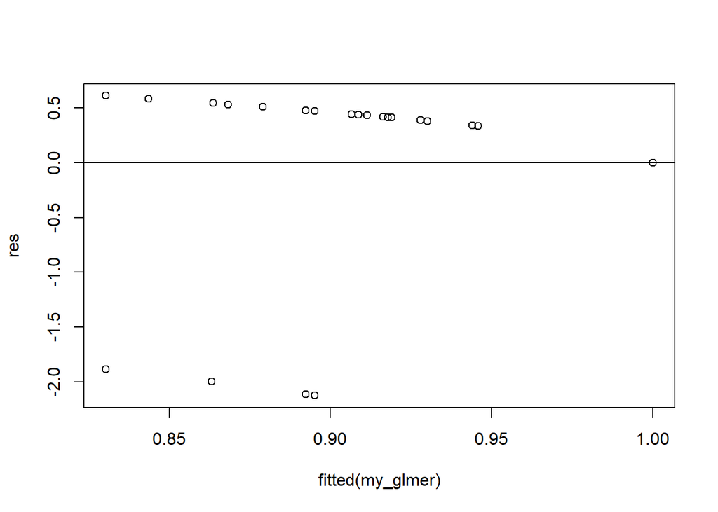

```r
res <- resid(my_glmer)
#produce residual vs. fitted plot
plot(fitted(my_glmer), res)

#add a horizontal line at 0
abline(0,0)
```

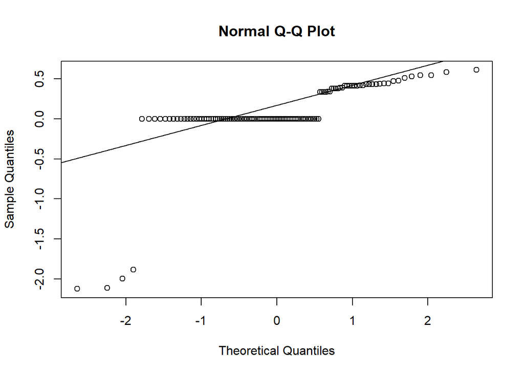

```r
#create Q-Q plot for residuals
qqnorm(res)

#add a straight diagonal line to the plot
qqline(res)
```

##### 2.2. Day 18

1. Run LMM for survival at day 18

```r
my_glmer1<- glmer(Survival_code ~ Site*Treatment + (1|Location), data=Juveniles_stat18_1, family = binomial)
summary(my_glmer1)
```

```
## Generalized linear mixed model fit by maximum likelihood (Laplace
##   Approximation) [glmerMod]
##  Family: binomial  ( logit )
## Formula: Survival_code ~ Site * Treatment + (1 | Location)
##    Data: Juveniles_stat18_1
##
##      AIC      BIC   logLik deviance df.resid
##     84.8    121.3    -29.4     58.8      109
##
## Scaled residuals:
##      Min       1Q   Median       3Q      Max
## -3.07651 -0.00003  0.00003  0.40997  2.33026
##
## Random effects:
##  Groups   Name        Variance Std.Dev.
##  Location (Intercept) 0.3544   0.5953
## Number of obs: 122, groups:  Location, 6
##
## Fixed effects:
##                               Estimate Std. Error z value Pr(>|z|)
## (Intercept)                     2.2346     1.1266   1.984   0.0473 *
## SiteBonny Hills                18.3283   340.4831   0.054   0.9571
## SiteCronulla                   -0.5097     1.3319  -0.383   0.7019
## SitePalm Beach                 -0.6213     1.3394  -0.464   0.6427
## TreatmentMHW1                  -0.6117     1.3386  -0.457   0.6477
## TreatmentMHW2                 -22.9213   846.9958  -0.027   0.9784
## SiteBonny Hills:TreatmentMHW1 -18.8558   340.4837  -0.055   0.9558
## SiteCronulla:TreatmentMHW1     18.6373   628.5206   0.030   0.9763
## SitePalm Beach:TreatmentMHW1   20.6494   519.1645   0.040   0.9683
## SiteBonny Hills:TreatmentMHW2   0.1482   808.5563   0.000   0.9999
## SiteCronulla:TreatmentMHW2     -0.4994   857.7094  -0.001   0.9995
## SitePalm Beach:TreatmentMHW2   19.0934   846.9961   0.023   0.9820
## ---
## Signif. codes:  0 '***' 0.001 '**' 0.01 '*' 0.05 '.' 0.1 ' ' 1
##
## Correlation of Fixed Effects:
##             (Intr) StBnnH StCrnl StPlmB TrMHW1 TrMHW2 SBH:TMHW1 SC:TMHW1
## SitBnnyHlls -0.001
## SiteCronull -0.772  0.001
## SitePalmBch -0.770  0.001  0.646
## TretmntMHW1 -0.768  0.000  0.646  0.643
## TretmntMHW2  0.001 -0.311 -0.001 -0.002 -0.001
## StBHl:TMHW1  0.001 -1.000 -0.001 -0.001 -0.002  0.311
## StCrn:TMHW1 -0.001 -0.138  0.001  0.001  0.001 -0.208  0.138
## StPBc:TMHW1  0.000  0.157  0.000  0.000  0.000 -0.074 -0.157    -0.044
## StBHl:TMHW2 -0.002 -0.095  0.002  0.003  0.002 -0.916  0.095     0.276
## StCrn:TMHW2  0.002 -0.155 -0.001 -0.002 -0.002  0.711  0.155    -0.274
## StPBc:TMHW2 -0.002  0.311  0.001  0.001  0.001 -1.000 -0.311     0.208
##             SPB:TMHW1 SBH:TMHW2 SC:TMHW2
## SitBnnyHlls
## SiteCronull
## SitePalmBch
## TretmntMHW1
## TretmntMHW2
## StBHl:TMHW1
## StCrn:TMHW1
## StPBc:TMHW1
## StBHl:TMHW2  0.011
## StCrn:TMHW2 -0.064    -0.680
## StPBc:TMHW2  0.074     0.916    -0.711
## optimizer (Nelder_Mead) convergence code: 0 (OK)
##  Hessian is numerically singular: parameters are not uniquely determined
```

```r
overdisp.glmer(my_glmer1)
```

```
## Residual deviance: 54.354 on 109 degrees of freedom (ratio: 0.499)
```

```r
my_glmer_anova <- car::Anova(my_glmer1)
my_glmer_anova
```

```
## Analysis of Deviance Table (Type II Wald chisquare tests)
##
## Response: Survival_code
##                  Chisq Df Pr(>Chisq)
## Site            0.4211  3   0.935858
## Treatment      11.7712  2   0.002779 **
## Site:Treatment  0.0076  6   1.000000
## ---
## Signif. codes:  0 '***' 0.001 '**' 0.01 '*' 0.05 '.' 0.1 ' ' 1
```

2. Post-hoc test

```r
emm3 <- emmeans(my_glmer1, specs = pairwise ~ Treatment, type = "response", adjust = "tukey")
```

```
## NOTE: Results may be misleading due to involvement in interactions
```

```r
summary(emm3)
```

```
## $emmeans
##  Treatment     prob      SE  df asymp.LCL asymp.UCL
##  Ambient   9.99e-01 0.12336 Inf  2.22e-16         1
##  MHW1      1.00e+00 0.00323 Inf  2.22e-16         1
##  MHW2      8.30e-06 0.00493 Inf  2.22e-16         1
##
## Results are averaged over the levels of: Site
## Confidence level used: 0.95
## Intervals are back-transformed from the logit scale
##
## $contrasts
##  contrast       odds.ratio       SE  df null z.ratio p.value
##  Ambient / MHW1   0.00e+00 2.00e+00 Inf    1  -0.021  0.9998
##  Ambient / MHW2   8.31e+07 5.19e+10 Inf    1   0.029  0.9995
##  MHW1 / MHW2      7.45e+09 5.01e+12 Inf    1   0.034  0.9994
##
## Results are averaged over the levels of: Site
## P value adjustment: tukey method for comparing a family of 3 estimates
## Tests are performed on the log odds ratio scale
```

3. Check model assumptions

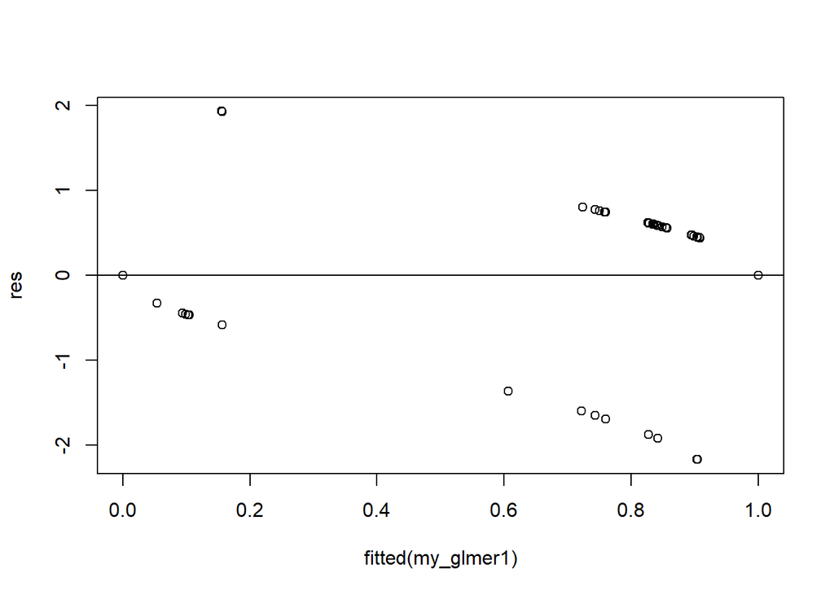

```r
res <- resid(my_glmer1)
#produce residual vs. fitted plot
plot(fitted(my_glmer1), res)

#add a horizontal line at 0
abline(0,0)
```

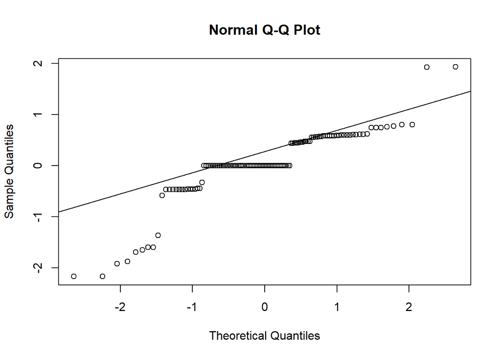

```r
#create Q-Q plot for residuals
qqnorm(res)

#add a straight diagonal line to the plot
qqline(res)
```

##### 2.3. Day 22

1. Run LMM for survival at day 22

```r
my_glmer1<- glmer(Survival_code ~ Site*Treatment + (1|Location), data=Juveniles_stat22_1, family = binomial)
summary(my_glmer1)
```

```
## Generalized linear mixed model fit by maximum likelihood (Laplace
##   Approximation) [glmerMod]
##  Family: binomial  ( logit )
## Formula: Survival_code ~ Site * Treatment + (1 | Location)
##    Data: Juveniles_stat22_1
##
##      AIC      BIC   logLik deviance df.resid
##     74.6     96.2    -28.3     56.6       73
##
## Scaled residuals:
##      Min       1Q   Median       3Q      Max
## -2.91312  0.00007  0.31820  0.43215  1.03905
##
## Random effects:
##  Groups   Name        Variance Std.Dev.
##  Location (Intercept) 0.8404   0.9167
## Number of obs: 82, groups:  Location, 6
##
## Fixed effects:
##                                 Estimate Std. Error z value Pr(>|z|)
## (Intercept)                      1.35408    0.93302   1.451    0.147
## SiteBonny Hills                 17.31347 3498.86652   0.005    0.996
## SiteCronulla                    -0.06772    1.10986  -0.061    0.951
## SitePalm Beach                   0.39728    1.20226   0.330    0.741
## TreatmentMHW1                    0.44688    1.19831   0.373    0.709
## SiteBonny Hills:TreatmentMHW1  -18.02184 3498.86673  -0.005    0.996
## SiteCronulla:TreatmentMHW1      17.19573 3155.80978   0.005    0.996
## SitePalm Beach:TreatmentMHW1     0.42733    1.84602   0.231    0.817
##
## Correlation of Fixed Effects:
##             (Intr) StBnnH StCrnl StPlmB TrMHW1 SBH:TM SC:TMH
## SitBnnyHlls  0.000
## SiteCronull -0.703  0.000
## SitePalmBch -0.652  0.000  0.550
## TretmntMHW1 -0.651  0.000  0.551  0.513
## StBHl:TMHW1  0.000 -1.000  0.000  0.000  0.000
## StCrn:TMHW1  0.000  0.000  0.000  0.000  0.000  0.000
## StPBc:TMHW1  0.428  0.000 -0.359 -0.651 -0.648  0.000  0.000
## optimizer (Nelder_Mead) convergence code: 0 (OK)
## unable to evaluate scaled gradient
## Model failed to converge: degenerate  Hessian with 1 negative eigenvalues
```

```r
overdisp.glmer(my_glmer1)
```

```
## Residual deviance: 48.954 on 73 degrees of freedom (ratio: 0.671)
```

```r
my_glmer_anova <- car::Anova(my_glmer1)
my_glmer_anova
```

```
## Analysis of Deviance Table (Type II Wald chisquare tests)
##
## Response: Survival_code
##                 Chisq Df Pr(>Chisq)
## Site           1.2830  3     0.7332
## Treatment      0.4715  1     0.4923
## Site:Treatment 0.0536  3     0.9967
```

2. Post-hoc test

```r
emm3 <- emmeans(my_glmer1, specs = pairwise ~ Treatment, type = "response", adjust = "tukey")
```

```
## NOTE: Results may be misleading due to involvement in interactions
```

```r
summary(emm3)
```

```
## $emmeans
##  Treatment  prob   SE  df asymp.LCL asymp.UCL
##  Ambient   0.997 2.73 Inf  2.22e-16         1
##  MHW1      0.998 1.74 Inf  2.22e-16         1
##
## Results are averaged over the levels of: Site
## Confidence level used: 0.95
## Intervals are back-transformed from the logit scale
##
## $contrasts
##  contrast       odds.ratio  SE  df null z.ratio p.value
##  Ambient / MHW1      0.707 832 Inf    1   0.000  0.9998
##
## Results are averaged over the levels of: Site
## Tests are performed on the log odds ratio scale
```

3. Check model assumptions

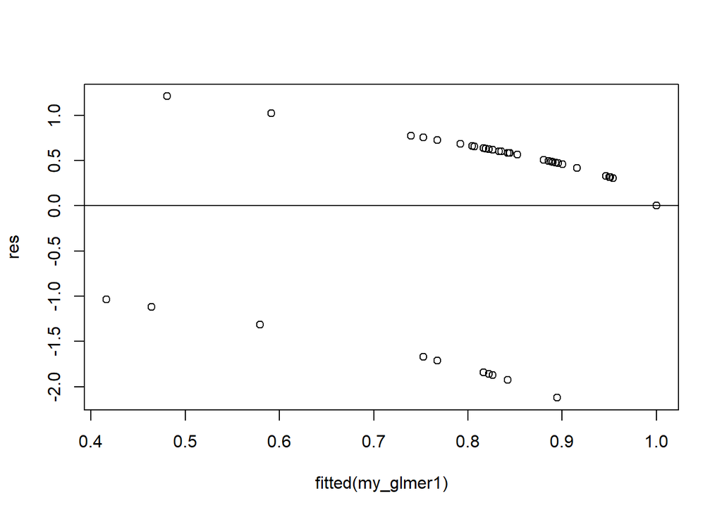

```r
res <- resid(my_glmer1)
#produce residual vs. fitted plot
plot(fitted(my_glmer1), res)

#add a horizontal line at 0
abline(0,0)
```

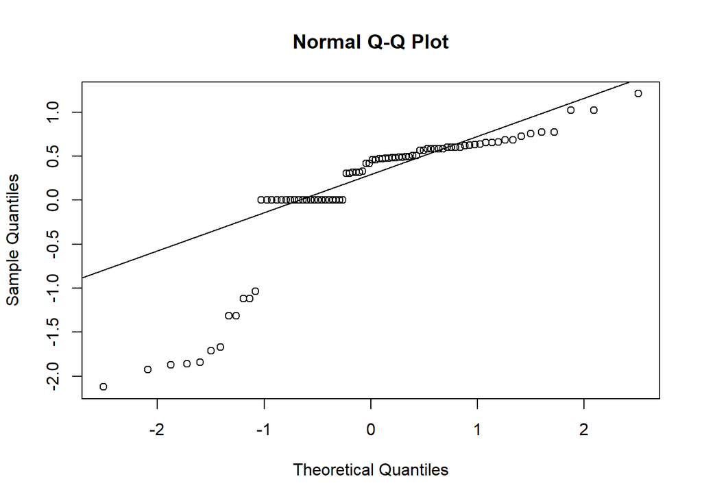

```r
#create Q-Q plot for residuals
qqnorm(res)

#add a straight diagonal line to the plot
qqline(res)
```

### **3b)** Structural intregrity loss

#### 1. Visualise differences

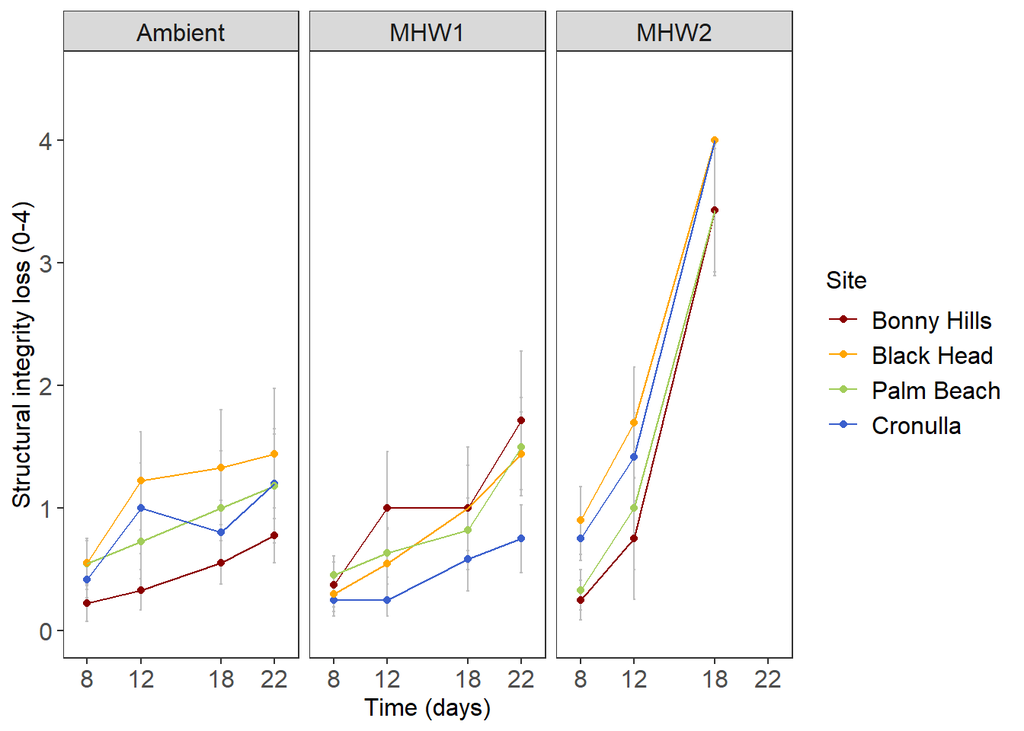

```r
Juv_means$Site <- factor(
  Juv_means$Site,
  levels = c("Bonny Hills","Black Head","Palm Beach","Cronulla"),
  labels = c(
    "Bonny Hills","Black Head","Palm Beach","Cronulla"
  ))

Juv_means$Day_equivalent1 <- as.numeric(Juv_means$Day_equivalent)
Melting_plot <- Juv_means %>%
  filter(Day_equivalent == 8|Day_equivalent == 12|Day_equivalent == 18| Day_equivalent == 22)  %>%
ggplot(aes(x= Day_equivalent, y= Mean_melting, colour = Site)) +
   geom_errorbar(aes(ymin=Mean_melting-se_melting, ymax=Mean_melting+se_melting),colour = "grey", width=.2) +
  geom_point() +
  geom_line()+
Theme1 +
labs( y="Structural integrity loss (0-4)", x="Time (days)")  +
 scale_colour_manual(values = c("darkred", "orange", "darkolivegreen3", "royalblue3"))   +
theme(strip.text.x = element_text(size = 12))+
scale_y_continuous(limits = c(0, 4.5), breaks = seq(0, 4, by = 1))+
scale_x_continuous(limits = c(7, 23), breaks = c(8, 12, 18,22))+
facet_wrap(~ factor(Treatment, c("Ambient","MHW1","MHW2")), ncol = 3)


Melting_plot
```

```r
ggsave("Melting_juv.jpeg", width = 220, height = 60, units = "mm")
```

#### 2. Statistical analyses

##### 2.1. Day 8

1. Run LMM for melting at day 8

```r
my_lmer<- lmer(Melting ~ Site*Treatment + (1|Location), data=Juveniles_stat8_1)
summary(my_lmer)
```

```
## Linear mixed model fit by REML ['lmerMod']
## Formula: Melting ~ Site * Treatment + (1 | Location)
##    Data: Juveniles_stat8_1
##
## REML criterion at convergence: 201
##
## Scaled residuals:
##     Min      1Q  Median      3Q     Max
## -1.9028 -0.6946 -0.2273  0.7249  3.3902
##
## Random effects:
##  Groups   Name        Variance Std.Dev.
##  Location (Intercept) 0.0623   0.2496
##  Residual             0.2655   0.5153
## Number of obs: 121, groups:  Location, 6
##
## Fixed effects:
##                               Estimate Std. Error t value
## (Intercept)                    0.55191    0.20095   2.747
## SiteBonny Hills               -0.28746    0.24350  -1.181
## SiteCronulla                  -0.13525    0.22830  -0.592
## SitePalm Beach                 0.02302    0.23313   0.099
## TreatmentMHW1                 -0.27969    0.23861  -1.172
## TreatmentMHW2                  0.37697    0.23813   1.583
## SiteBonny Hills:TreatmentMHW1  0.47657    0.34563   1.379
## SiteCronulla:TreatmentMHW1     0.11303    0.31810   0.355
## SitePalm Beach:TreatmentMHW1   0.15125    0.32539   0.465
## SiteBonny Hills:TreatmentMHW2 -0.30834    0.34482  -0.894
## SiteCronulla:TreatmentMHW2    -0.04364    0.31773  -0.137
## SitePalm Beach:TreatmentMHW2  -0.57634    0.33272  -1.732
##
## Correlation of Fixed Effects:
##             (Intr) StBnnH StCrnl StPlmB TrMHW1 TrMHW2 SBH:TMHW1 SC:TMHW1
## SitBnnyHlls -0.609
## SiteCronull -0.654  0.536
## SitePalmBch -0.642  0.527  0.565
## TretmntMHW1 -0.628  0.513  0.553  0.542
## TretmntMHW2 -0.624  0.514  0.549  0.538  0.526
## StBHl:TMHW1  0.428 -0.700 -0.377 -0.368 -0.686 -0.359
## StCrn:TMHW1  0.471 -0.385 -0.719 -0.407 -0.750 -0.395  0.515
## StPBc:TMHW1  0.464 -0.379 -0.409 -0.720 -0.736 -0.389  0.503     0.552
## StBHl:TMHW2  0.428 -0.704 -0.377 -0.369 -0.360 -0.685  0.494     0.270
## StCrn:TMHW2  0.468 -0.385 -0.717 -0.403 -0.394 -0.749  0.269     0.515
## StPBc:TMHW2  0.451 -0.369 -0.397 -0.700 -0.381 -0.717  0.259     0.286
##             SPB:TMHW1 SBH:TMHW2 SC:TMHW2
## SitBnnyHlls
## SiteCronull
## SitePalmBch
## TretmntMHW1
## TretmntMHW2
## StBHl:TMHW1
## StCrn:TMHW1
## StPBc:TMHW1
## StBHl:TMHW2  0.265
## StCrn:TMHW2  0.292     0.513
## StPBc:TMHW2  0.506     0.490     0.537
```

```r
my_glmer_anova <- car::Anova(my_lmer)
my_glmer_anova
```

```
## Analysis of Deviance Table (Type II Wald chisquare tests)
##
## Response: Melting
##                 Chisq Df Pr(>Chisq)
## Site           2.8005  3     0.4234
## Treatment      5.6570  2     0.0591 .
## Site:Treatment 9.6855  6     0.1385
## ---
## Signif. codes:  0 '***' 0.001 '**' 0.01 '*' 0.05 '.' 0.1 ' ' 1
```

2. Check model assumptions

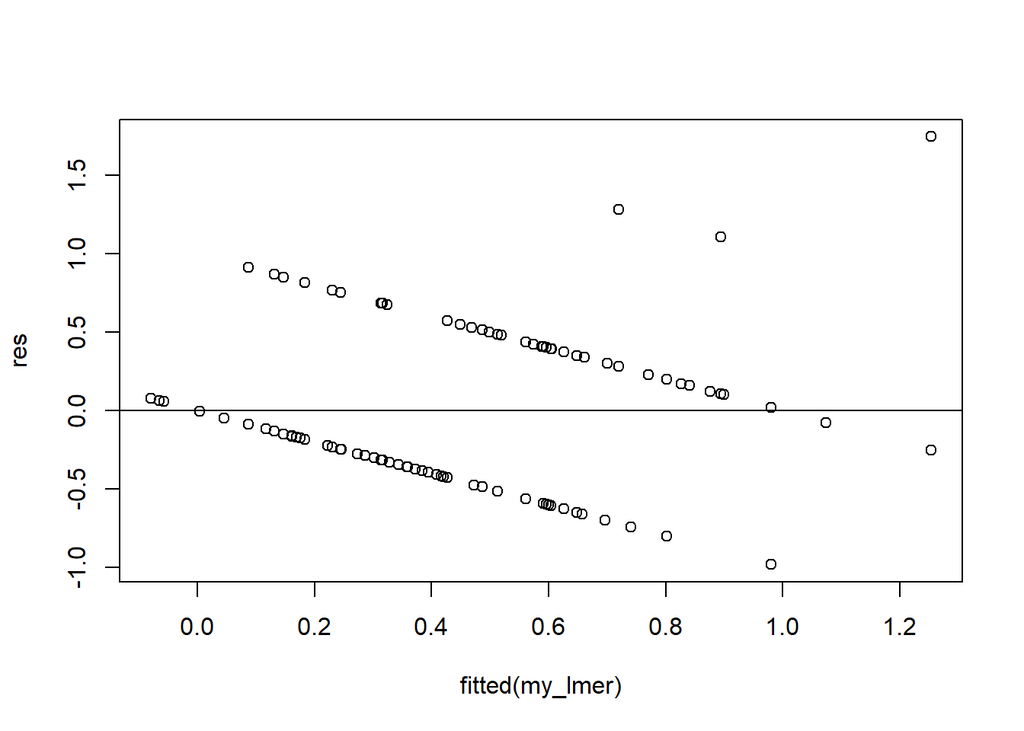

```r
res <- resid(my_lmer)
#produce residual vs. fitted plot
plot(fitted(my_lmer), res)

#add a horizontal line at 0
abline(0,0)
```

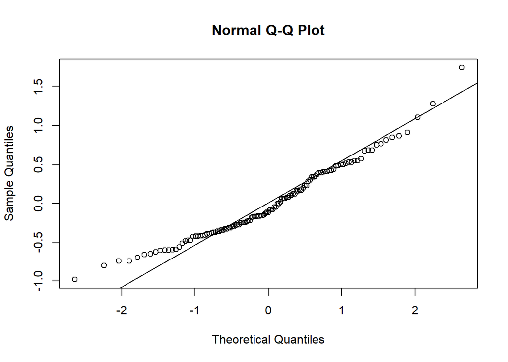

```r
#create Q-Q plot for residuals
qqnorm(res)

#add a straight diagonal line to the plot
qqline(res)
```

##### 2.2. Day 12

1. Run LMM for melting at day 12

```r
my_glmer<- lmer(Melting ~ Site*Treatment + (1|Location), data=Juveniles_stat12_1)
summary(my_glmer)
```

```
## Linear mixed model fit by REML ['lmerMod']
## Formula: Melting ~ Site * Treatment + (1 | Location)
##    Data: Juveniles_stat12_1
##
## REML criterion at convergence: 354.9
##
## Scaled residuals:
##     Min      1Q  Median      3Q     Max
## -1.6123 -0.6640 -0.1742  0.3761  3.0624
##
## Random effects:
##  Groups   Name        Variance Std.Dev.
##  Location (Intercept) 0.1835   0.4284
##  Residual             1.0724   1.0355
## Number of obs: 122, groups:  Location, 6
##
## Fixed effects:
##                               Estimate Std. Error t value
## (Intercept)                    1.26816    0.38938   3.257
## SiteBonny Hills               -0.85786    0.48930  -1.753
## SiteCronulla                  -0.26816    0.45868  -0.585
## SitePalm Beach                -0.52161    0.46833  -1.114
## TreatmentMHW1                 -0.73542    0.46821  -1.571
## TreatmentMHW2                  0.54142    0.47839   1.132
## SiteBonny Hills:TreatmentMHW1  1.45009    0.68672   2.112
## SiteCronulla:TreatmentMHW1    -0.01458    0.63083  -0.023
## SitePalm Beach:TreatmentMHW1   0.61912    0.64556   0.959
## SiteBonny Hills:TreatmentMHW2 -0.05573    0.69297  -0.080
## SiteCronulla:TreatmentMHW2    -0.12475    0.63842  -0.195
## SitePalm Beach:TreatmentMHW2  -0.21101    0.66849  -0.316
##
## Correlation of Fixed Effects:
##             (Intr) StBnnH StCrnl StPlmB TrMHW1 TrMHW2 SBH:TMHW1 SC:TMHW1
## SitBnnyHlls -0.631
## SiteCronull -0.678  0.536
## SitePalmBch -0.665  0.527  0.565
## TretmntMHW1 -0.665  0.525  0.565  0.554
## TretmntMHW2 -0.647  0.514  0.549  0.538  0.538
## StBHl:TMHW1  0.448 -0.709 -0.380 -0.372 -0.678 -0.363
## StCrn:TMHW1  0.494 -0.390 -0.728 -0.411 -0.742 -0.400  0.503
## StPBc:TMHW1  0.486 -0.384 -0.413 -0.728 -0.728 -0.393  0.491     0.541
## StBHl:TMHW2  0.444 -0.704 -0.377 -0.369 -0.368 -0.685  0.500     0.273
## StCrn:TMHW2  0.485 -0.385 -0.717 -0.403 -0.403 -0.749  0.272     0.521
## StPBc:TMHW2  0.467 -0.369 -0.396 -0.700 -0.389 -0.717  0.261     0.289
##             SPB:TMHW1 SBH:TMHW2 SC:TMHW2
## SitBnnyHlls
## SiteCronull
## SitePalmBch
## TretmntMHW1
## TretmntMHW2
## StBHl:TMHW1
## StCrn:TMHW1
## StPBc:TMHW1
## StBHl:TMHW2  0.268
## StCrn:TMHW2  0.295     0.513
## StPBc:TMHW2  0.511     0.491     0.537
```

```r
my_glmer_anova <- car::Anova(my_glmer)
my_glmer_anova
```

```
## Analysis of Deviance Table (Type II Wald chisquare tests)
##
## Response: Melting
##                  Chisq Df Pr(>Chisq)
## Site            2.6549  3   0.447940
## Treatment      10.4329  2   0.005427 **
## Site:Treatment  8.4187  6   0.209003
## ---
## Signif. codes:  0 '***' 0.001 '**' 0.01 '*' 0.05 '.' 0.1 ' ' 1
```

```r
overdisp.glmer(my_glmer)
```

```
## Residual deviance: 113.828 on 109 degrees of freedom (ratio: 1.044)
```

2. Post-hoc test

```r
emm3 <- emmeans(my_glmer, specs = pairwise ~ Treatment, type = "response", adjust = "tukey")
```

```
## NOTE: Results may be misleading due to involvement in interactions
```

```r
summary(emm3)
```

```
## $emmeans
##  Treatment emmean    SE   df lower.CL upper.CL
##  Ambient    0.856 0.240 10.3    0.324     1.39
##  MHW1       0.634 0.238 10.2    0.104     1.16
##  MHW2       1.300 0.244 10.9    0.762     1.84
##
## Results are averaged over the levels of: Site
## Degrees-of-freedom method: kenward-roger
## Confidence level used: 0.95
##
## $contrasts
##  contrast       estimate    SE  df t.ratio p.value
##  Ambient - MHW1    0.222 0.230 105   0.963  0.6018
##  Ambient - MHW2   -0.444 0.235 106  -1.886  0.1478
##  MHW1 - MHW2      -0.665 0.234 106  -2.838  0.0149
##
## Results are averaged over the levels of: Site
## Degrees-of-freedom method: kenward-roger
## P value adjustment: tukey method for comparing a family of 3 estimates
```

3. Check model assumptions

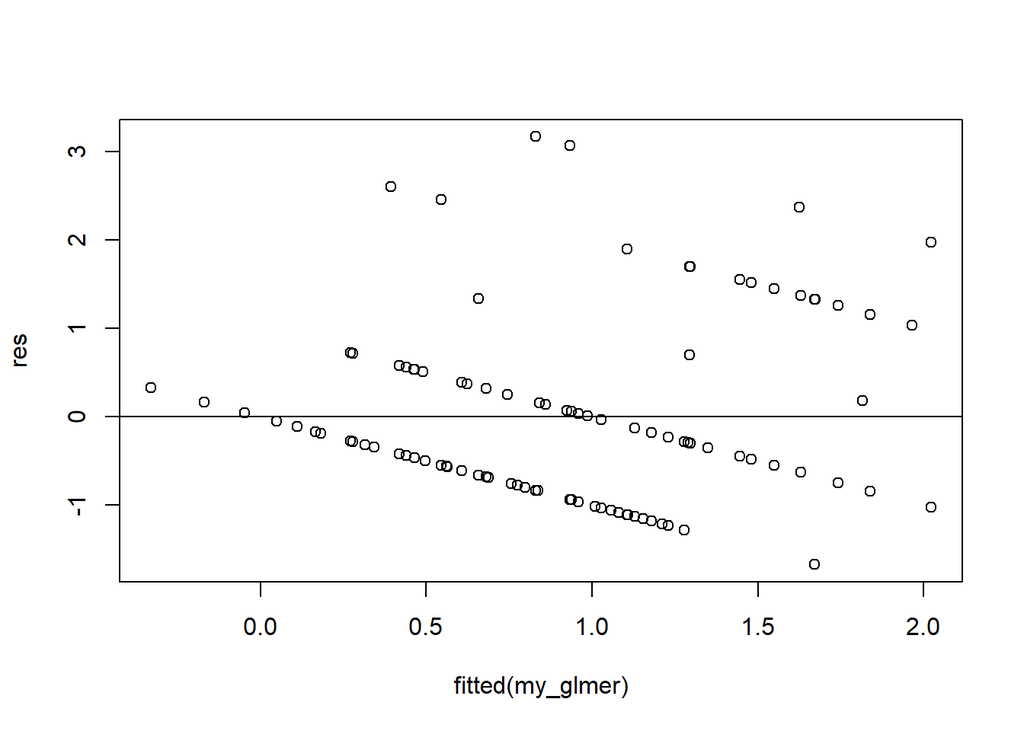

```r
res <- resid(my_glmer)
#produce residual vs. fitted plot
plot(fitted(my_glmer), res)

#add a horizontal line at 0
abline(0,0)
```

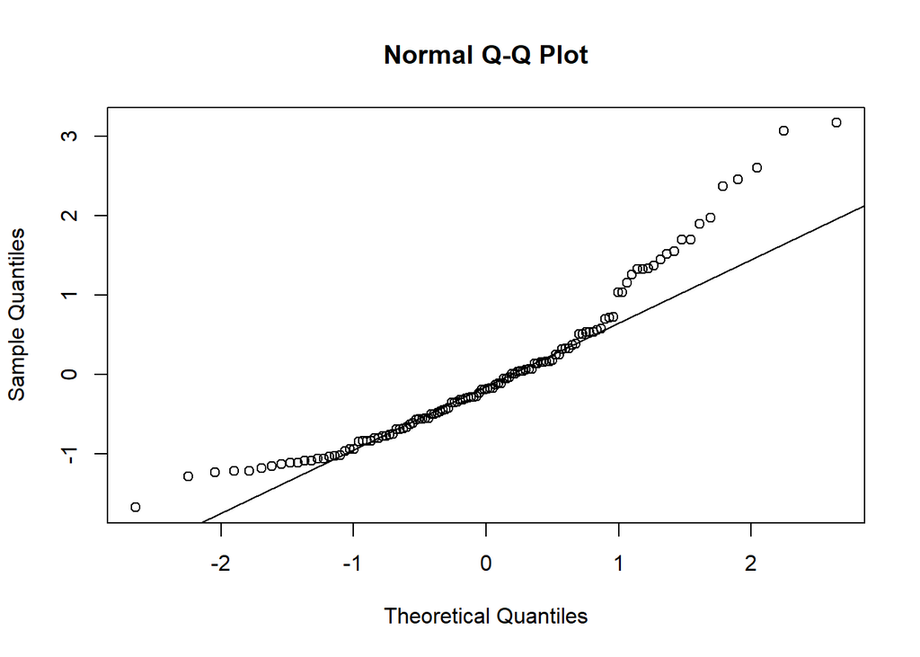

```r
#create Q-Q plot for residuals
qqnorm(res)

#add a straight diagonal line to the plot
qqline(res)
```

##### 2.3. Day 18

1. Run LMM for melting at day 18

```r
my_glmer1<- lmer(Melting ~ Site*Treatment + (1|Location), data=Juveniles_stat18_1)
summary(my_glmer1)
```

```
## Linear mixed model fit by REML ['lmerMod']
## Formula: Melting ~ Site * Treatment + (1 | Location)
##    Data: Juveniles_stat18_1
##
## REML criterion at convergence: 313.3
##
## Scaled residuals:
##      Min       1Q   Median       3Q      Max
## -2.80568 -0.55760 -0.04844  0.40106  2.76310
##
## Random effects:
##  Groups   Name        Variance Std.Dev.
##  Location (Intercept) 0.1388   0.3726
##  Residual             1.1359   1.0658
## Number of obs: 107, groups:  Location, 6
##
## Fixed effects:
##                                Estimate Std. Error t value
## (Intercept)                    1.264059   0.389187   3.248
## SiteBonny Hills               -0.700787   0.503644  -1.391
## SiteCronulla                  -0.475431   0.490309  -0.970
## SitePalm Beach                -0.247407   0.482187  -0.513
## TreatmentMHW1                 -0.242245   0.493656  -0.491
## TreatmentMHW2                  2.820516   0.564411   4.997
## SiteBonny Hills:TreatmentMHW1  0.845458   0.729836   1.158
## SiteCronulla:TreatmentMHW1     0.036950   0.670601   0.055
## SitePalm Beach:TreatmentMHW1  -0.002566   0.673776  -0.004
## SiteBonny Hills:TreatmentMHW2  0.116276   0.778468   0.149
## SiteCronulla:TreatmentMHW2     0.427020   0.757153   0.564
## SitePalm Beach:TreatmentMHW2  -0.341099   0.764936  -0.446
##
## Correlation of Fixed Effects:
##             (Intr) StBnnH StCrnl StPlmB TrMHW1 TrMHW2 SBH:TMHW1 SC:TMHW1
## SitBnnyHlls -0.650
## SiteCronull -0.667  0.514
## SitePalmBch -0.685  0.527  0.539
## TretmntMHW1 -0.671  0.515  0.527  0.544
## TretmntMHW2 -0.580  0.448  0.460  0.469  0.459
## StBHl:TMHW1  0.449 -0.687 -0.353 -0.363 -0.672 -0.303
## StCrn:TMHW1  0.490 -0.377 -0.732 -0.397 -0.732 -0.337  0.492
## StPBc:TMHW1  0.495 -0.380 -0.387 -0.721 -0.737 -0.339  0.493     0.538
## StBHl:TMHW2  0.422 -0.647 -0.333 -0.341 -0.333 -0.722  0.444     0.244
## StCrn:TMHW2  0.433 -0.335 -0.648 -0.351 -0.344 -0.743  0.230     0.476
## StPBc:TMHW2  0.433 -0.332 -0.340 -0.631 -0.345 -0.735  0.230     0.251
##             SPB:TMHW1 SBH:TMHW2 SC:TMHW2
## SitBnnyHlls
## SiteCronull
## SitePalmBch
## TretmntMHW1
## TretmntMHW2
## StBHl:TMHW1
## StCrn:TMHW1
## StPBc:TMHW1
## StBHl:TMHW2  0.246
## StCrn:TMHW2  0.254     0.538
## StPBc:TMHW2  0.456     0.533     0.549
```

```r
overdisp.glmer(my_glmer1)
```

```
## Residual deviance: 104.119 on 94 degrees of freedom (ratio: 1.108)
```

```r
my_glmer_anova <- car::Anova(my_glmer1)
my_glmer_anova
```

```
## Analysis of Deviance Table (Type II Wald chisquare tests)
##
## Response: Melting
##                   Chisq Df Pr(>Chisq)
## Site             2.1805  3     0.5358
## Treatment      149.3260  2     <2e-16 ***
## Site:Treatment   3.6147  6     0.7286
## ---
## Signif. codes:  0 '***' 0.001 '**' 0.01 '*' 0.05 '.' 0.1 ' ' 1
```

2. Post-hoc test

```r
emm3 <- emmeans(my_glmer1, specs = pairwise ~ Treatment, type = "response", adjust = "tukey")
```

```
## NOTE: Results may be misleading due to involvement in interactions
```

```r
summary(emm3)
```

```
## $emmeans
##  Treatment emmean    SE   df lower.CL upper.CL
##  Ambient    0.908 0.231 11.4    0.403     1.41
##  MHW1       0.886 0.231 11.5    0.381     1.39
##  MHW2       3.779 0.260 16.5    3.229     4.33
##
## Results are averaged over the levels of: Site
## Degrees-of-freedom method: kenward-roger
## Confidence level used: 0.95
##
## $contrasts
##  contrast       estimate    SE   df t.ratio p.value
##  Ambient - MHW1   0.0223 0.244 90.9   0.091  0.9954
##  Ambient - MHW2  -2.8711 0.269 91.9 -10.675  <.0001
##  MHW1 - MHW2     -2.8933 0.270 92.3 -10.701  <.0001
##
## Results are averaged over the levels of: Site
## Degrees-of-freedom method: kenward-roger
## P value adjustment: tukey method for comparing a family of 3 estimates
```

3. Check model assumptions

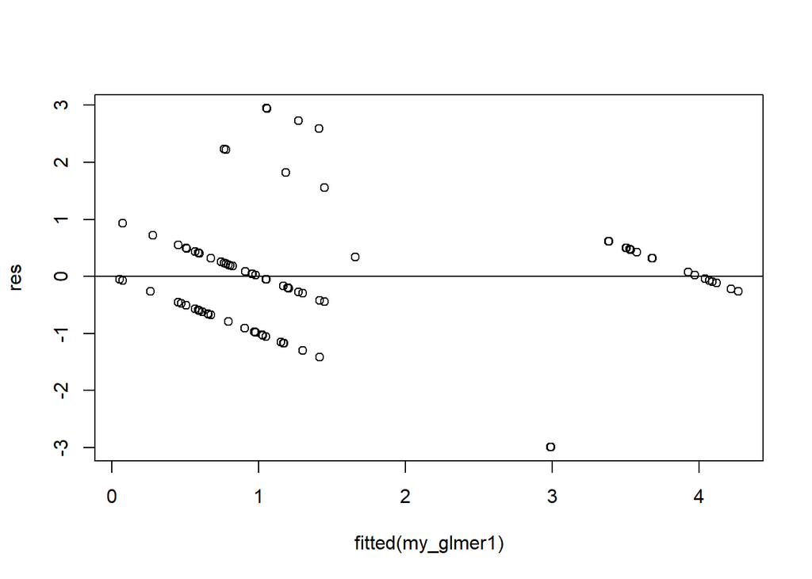

```r
res <- resid(my_glmer1)
#produce residual vs. fitted plot
plot(fitted(my_glmer1), res)

#add a horizontal line at 0
abline(0,0)
```

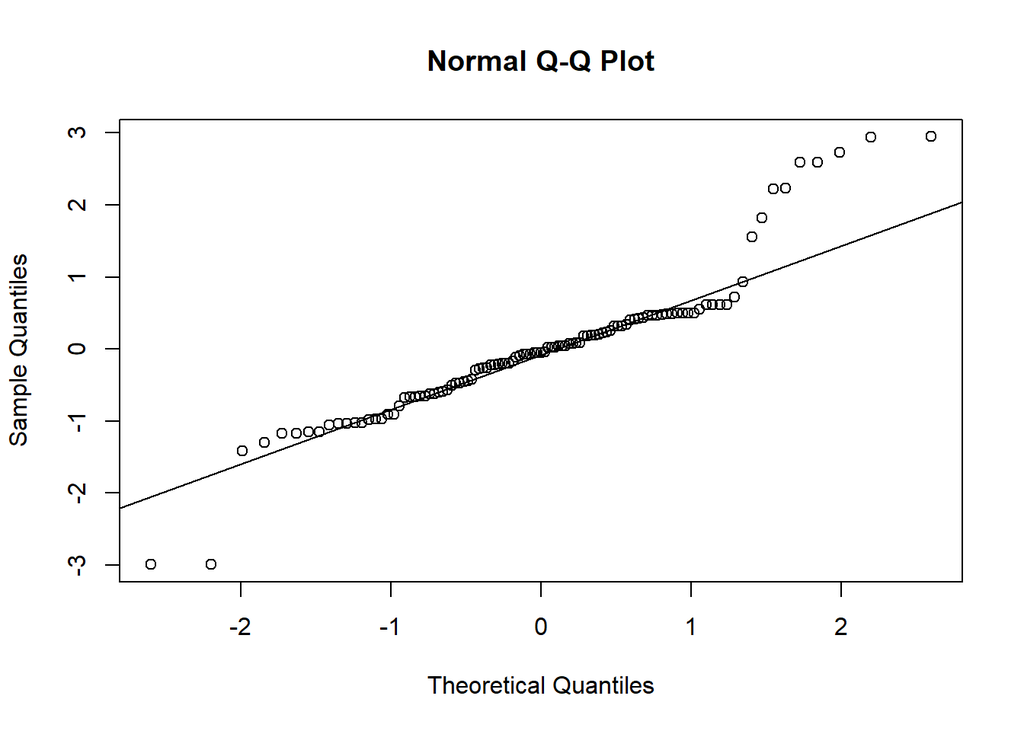

```r
#create Q-Q plot for residuals
qqnorm(res)

#add a straight diagonal line to the plot
qqline(res)
```

##### 2.4. Day 22

1. Run LMM for melting at day 22

```r
my_glmer1<- lmer(Melting ~ Site*Treatment + (1|Location), data=Juveniles_stat22_1)
summary(my_glmer1)
```

```
## Linear mixed model fit by REML ['lmerMod']
## Formula: Melting ~ Site * Treatment + (1 | Location)
##    Data: Juveniles_stat22_1
##
## REML criterion at convergence: 245.4
##
## Scaled residuals:
##     Min      1Q  Median      3Q     Max
## -1.8223 -0.7329 -0.1168  0.3833  2.2210
##
## Random effects:
##  Groups   Name        Variance Std.Dev.
##  Location (Intercept) 0.2738   0.5233
##  Residual             1.4478   1.2032
## Number of obs: 77, groups:  Location, 6
##
## Fixed effects:
##                               Estimate Std. Error t value
## (Intercept)                    1.46078    0.45863   3.185
## SiteBonny Hills               -0.60545    0.56923  -1.064
## SiteCronulla                  -0.21399    0.55384  -0.386
## SitePalm Beach                -0.25805    0.54587  -0.473
## TreatmentMHW1                 -0.05691    0.57677  -0.099
## SiteBonny Hills:TreatmentMHW1  1.18794    0.83768   1.418
## SiteCronulla:TreatmentMHW1    -0.43988    0.77021  -0.571
## SitePalm Beach:TreatmentMHW1   0.29234    0.78338   0.373
##
## Correlation of Fixed Effects:
##             (Intr) StBnnH StCrnl StPlmB TrMHW1 SBH:TM SC:TMH
## SitBnnyHlls -0.625
## SiteCronull -0.641  0.514
## SitePalmBch -0.660  0.528  0.539
## TretmntMHW1 -0.629  0.500  0.512  0.532
## StBHl:TMHW1  0.427 -0.676 -0.348 -0.359 -0.683
## StCrn:TMHW1  0.466 -0.372 -0.721 -0.393 -0.742  0.508
## StPBc:TMHW1  0.468 -0.373 -0.379 -0.705 -0.739  0.500  0.547
```

```r
overdisp.glmer(my_glmer1)
```

```
## Residual deviance: 94.844 on 68 degrees of freedom (ratio: 1.395)
```

```r
my_glmer_anova <- car::Anova(my_glmer1)
my_glmer_anova
```

```
## Analysis of Deviance Table (Type II Wald chisquare tests)
##
## Response: Melting
##                 Chisq Df Pr(>Chisq)
## Site           1.7962  3     0.6158
## Treatment      0.2691  1     0.6040
## Site:Treatment 4.3079  3     0.2301
```

2. Post-hoc test

```r
emm3 <- emmeans(my_glmer1, specs = pairwise ~ Treatment, type = "response", adjust = "tukey")
```

```
## NOTE: Results may be misleading due to involvement in interactions
```

```r
summary(emm3)
```

```
## $emmeans
##  Treatment emmean    SE   df lower.CL upper.CL
##  Ambient     1.19 0.290 8.11    0.523     1.86
##  MHW1        1.39 0.293 8.50    0.725     2.06
##
## Results are averaged over the levels of: Site
## Degrees-of-freedom method: kenward-roger
## Confidence level used: 0.95
##
## $contrasts
##  contrast       estimate    SE   df t.ratio p.value
##  Ambient - MHW1   -0.203 0.281 65.1  -0.723  0.4722
##
## Results are averaged over the levels of: Site
## Degrees-of-freedom method: kenward-roger
```

3. Check model assumptions

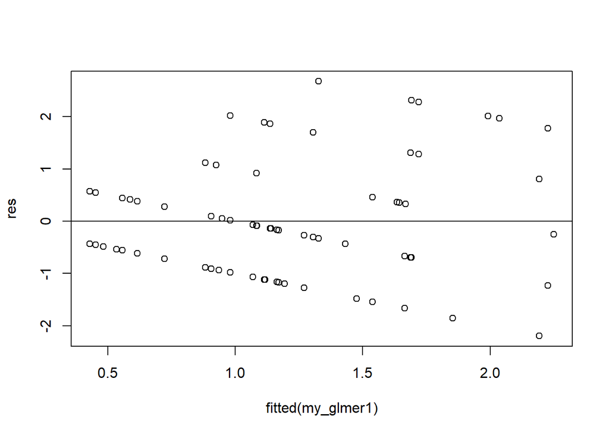

```r
res <- resid(my_glmer1)
#produce residual vs. fitted plot
plot(fitted(my_glmer1), res)

#add a horizontal line at 0
abline(0,0)
```

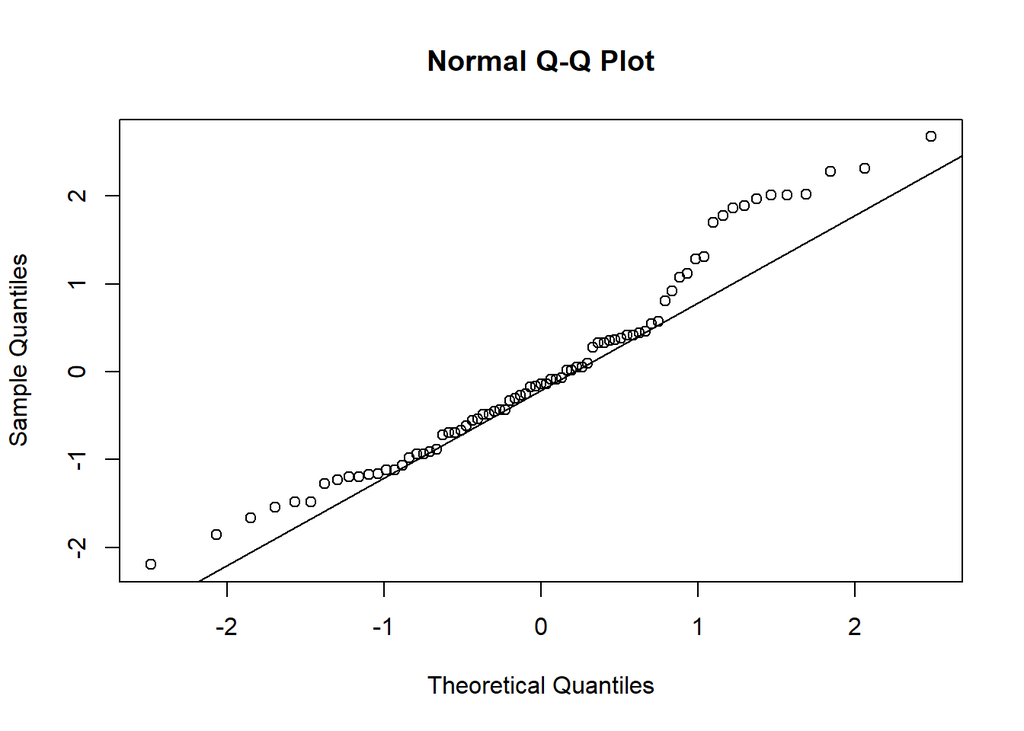

```r
#create Q-Q plot for residuals
qqnorm(res)

#add a straight diagonal line to the plot
qqline(res)
```